# Credit Card Transactions Project

**Author: Sixian Chen**

The Office of Management and Enterprise Services in the State of Oklahoma has made its purchase credit card transactions available. This dataset contains information on purchases made through the purchase card programs administered by the state and higher education institutions.

The purpose of this project is to create various features from raw dataset and detect fraudulent credit card transactions using these features.

Your can download data from [here](https://data.ok.gov/dataset/purchase-card-pcard-fiscal-year-2014).

# Table of Contents

- Section 1 Data Preparation
- Section 2 Initial observations
- Section 3 Feature Engineering
  - 3.1 Feature 1: The ratio to average amount
  - 3.2 Feature 2: The ratio to the median amount
  - 3.3 Feature 3: The ratio to Average amount spending by month
  - 3.4 Feature 4: The ratio to Average amount spending by week number
  - 3.5 Feature 5: The ratio to average amount spending of day of week
  - 3.6 Feature 6: The ratio to Average amount spent per day over the past 30 days
  - 3.7 Feature 7: The ratio to Average amount spent over the past 90 days
  - 3.8 Feature 8: The ratio to number of transactions by month
  - 3.9 Feature 9: The ratio to average number of transactions by week number
  - 3.10 Feature 10: The ratio to average number of transactions by day of week
  - 3.11 Feature 11: The ratio to average number of transactions during the past 30 days
  - 3.12 Feature 12: The ratio to average number of transactions during the past 60 days
  - 3.13 Feature 13: The ratio to average amount at "Vendor" level
  - 3.14 Feature 14: The ratio to median amount at "Vendor" level
  - 3.15 Feature 15: The ratio to median amount by month at 'Vendor' level
  - Create final dataset
- Section 4 Modeling
  - 4.1 Default KNN model
  - 4.2 Aggregating Multiple KNN Models
- Section 5 Conclusion

## Section 1 Data Preparation

Back to Table of Contents

```python
import pandas as pd
import numpy as np
df = pd.read_csv('purchase_credit_card.csv') #, encoding = "ISO-8859-1")
df.head(5)
```

|  | Year-Month | Agency Number | Agency Name | Cardholder Last Name | Cardholder First Initial | Description | Amount | Vendor | Transaction Date | Posted Date | Merchant Category Code (MCC) |
| --- | --- | --- | --- | --- | --- | --- | --- | --- | --- | --- | --- |
| 0 | 201307 | 1000 | OKLAHOMA STATE UNIVERSITY | Mason | C | GENERAL PURCHASE | 890.00 | NACAS | 07/30/2013 12:00:00 AM | 07/31/2013 12:00:00 AM | CHARITABLE AND SOCIAL SERVICE ORGANIZATIONS |
| 1 | 201307 | 1000 | OKLAHOMA STATE UNIVERSITY | Mason | C | ROOM CHARGES | 368.96 | SHERATON HOTEL | 07/30/2013 12:00:00 AM | 07/31/2013 12:00:00 AM | SHERATON |
| 2 | 201307 | 1000 | OKLAHOMA STATE UNIVERSITY | Massey | J | GENERAL PURCHASE | 165.82 | SEARS.COM 9300 | 07/29/2013 12:00:00 AM | 07/31/2013 12:00:00 AM | DIRCT MARKETING/DIRCT MARKETERS--NOT ELSEWHERE... |
| 3 | 201307 | 1000 | OKLAHOMA STATE UNIVERSITY | Massey | T | GENERAL PURCHASE | 96.39 | WAL-MART #0137 | 07/30/2013 12:00:00 AM | 07/31/2013 12:00:00 AM | GROCERY STORES,AND SUPERMARKETS |
| 4 | 201307 | 1000 | OKLAHOMA STATE UNIVERSITY | Mauro-Herrera | M | HAMMERMILL COPY PLUS COPY EA | 125.96 | STAPLES DIRECT | 07/30/2013 12:00:00 AM | 07/31/2013 12:00:00 AM | STATIONERY, OFFICE SUPPLIES, PRINTING AND WRIT... |

```python
# check dimensions of the dataset, we found it has 442458 rows and 11 columns
print(df.shape)
print(df.columns) # check column names
df.describe() # Get the Simple Summary Statistics
```

```
(442458, 11)
Index(['Year-Month', 'Agency Number', 'Agency Name', 'Cardholder Last Name',
       'Cardholder First Initial', 'Description', 'Amount', 'Vendor',
       'Transaction Date', 'Posted Date', 'Merchant Category Code (MCC)'],
      dtype='object')
```

|  | Year-Month | Agency Number | Amount |
| --- | --- | --- | --- |
| count | 442458.000000 | 442458.000000 | 4.424580e+05 |
| mean | 201357.284375 | 42785.860353 | 4.249912e+02 |
| std | 47.107417 | 33378.461293 | 5.266509e+03 |
| min | 201307.000000 | 1000.000000 | -4.286304e+04 |
| 25% | 201309.000000 | 1000.000000 | 3.091000e+01 |
| 50% | 201401.000000 | 47700.000000 | 1.048900e+02 |
| 75% | 201404.000000 | 76000.000000 | 3.450000e+02 |
| max | 201406.000000 | 98000.000000 | 1.903858e+06 |

```python
# change column names
df.columns = ['Year_Month', 'Agency_Number', 'Agency_Name', 'Cardholder_Last_Name',
      'Cardholder_First_Initial', 'Description', 'Amount', 'Vendor', 'Transaction_Date',
      'Posted_Date', 'Merchant_Category']

# Correct wrong agency name
df['Agency_Name'] = np.where(df['Agency_Name'] == '`DEPARTMENT OF EDUCATION', 'DEPARTMENT OF EDUCATION', df['Agency_Name'])
```

```python
#Creating separate Year and Month columns for future feature engineering
# Converting Transaction_Date and Posted_date from Python Object data type to datetime
df['Transaction_Date']=pd.to_datetime(df['Transaction_Date'])
df['Posted_Date']=pd.to_datetime(df['Posted_Date'])

df['Year_Month'].dtype
df['Year_Month']=pd.to_datetime(df['Year_Month'], format='%Y%m')
df['Year'] = df['Year_Month'].dt.year
df['Month'] = df['Year_Month'].dt.month
#Creating 'Week_Number' from 'Transaction_Date'
df['Week_Number'] = df['Transaction_Date'].dt.isocalendar().week

#Creating 'Day_of_Week' from 'Transaction_Date'
dayOfWeek={0:'Monday', 1:'Tuesday', 2:'Wednesday', 3:'Thursday', 4:'Friday', 5:'Saturday', 6:'Sunday'}
df['Day_of_Week'] = df['Transaction_Date'].dt.dayofweek.map(dayOfWeek)

df['Day_of_Week'].value_counts()
```

```
Wednesday    89644
Thursday     87537
Tuesday      86919
Friday       79917
Monday       61809
Saturday     26307
Sunday       10325
Name: Day_of_Week, dtype: int64
```

### Remove negative transactions

The original dataset contains transactions with negative amounts. This happens when a cardholder purchased an item (an expense transaction) but then receive his money back. Since our object is to detect fraud transactions, we will remove these negative transactions from our dataset.

```python
df[df['Amount']<0].shape # We have 14531 transactions with negative amounts.
```

```
(14531, 15)
```

```python
df = df[df['Amount']>0]
```

### Train-test split

Next, we split our dataset into 80% training set and 20% test set.

```python
from sklearn.model_selection import train_test_split
train, test = train_test_split(df, test_size=0.2, random_state=42)
print(train.shape)
print(test.shape)
```

```
(342341, 15)
(85586, 15)
```

## Section 2 Initial observations

Back to Table of Contents

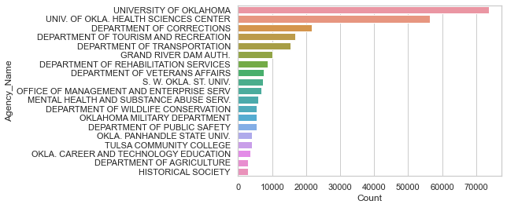

```python
import numpy as np
import plotly
import pandas as pd
import plotly.express as px

# Summarize the count statistics by agency_name in df_count
df_count = df['Agency_Name'].value_counts()
df_count = pd.DataFrame(df_count).reset_index()
df_count.columns = ['Agency_Name','Count']

fig = px.bar(df_count, x='Agency_Name', y='Count', color = 'Agency_Name', width=1000, height=400)
import seaborn as sns
sns.set_theme(style="whitegrid")
sns.barplot(y="Agency_Name", x="Count", data=df_count[1:20])
```

```
[Text(0.5, 1.0, 'Distribution of day of week')]
```

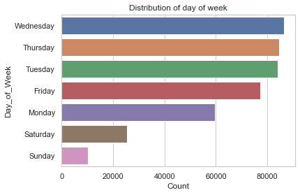

```python
df_count = df['Day_of_Week'].value_counts()
df_count = pd.DataFrame(df_count).reset_index()
df_count.columns = ['Day_of_Week','Count']
sns.barplot(y="Day_of_Week", x="Count", data=df_count).set(title= "Distribution of day of week")
```

## Section 3 Feature Engineering

Back to Table of Contents

Instructions:

- Understand the data grain: each row is a cardholder (last name + first name)
- An agency can have multiple cardholders. A corporate card (agency_name) can be used by many cardholders and these cardholders have to follow the corporation policy.
- Intuition: One or two cardholders may abuse their corporate cards. If we compare a cardholder to his agency, we can find outliers.
- The spending for a merchant category can be higher than others. It does not make sense to compare the spending of a merchant category to another. An agency can spend on various merchant categories, and you cannot claim anomalies just because the spending on one merchant category is higher than another.
- Anomaly detection is about "comparing a transaction to a benchmark". What is the right benchmark?
- So we will aggregate to the Aggrecy_Name level and card holder level then build features.
- Common sense tells us the comparison should be at "Agency_Name" and "Merchant_Category" level.
- We need to create features for both training set and test set.

### 3.1 Feature 1: The ratio to average amount

Back to Table of Contents

My thought process:

- The benchmark of this feature is the average amount of trasaction.
- We can compare each transaction's amount to the average amount of transaction at "Agency_Name" and "Merchant_Category" level.

```python
# create average spending group by agency and merchant category
stat_by_agency = train.groupby(['Agency_Name', 'Merchant_Category'])['Amount'].mean()
stat_by_agency = pd.DataFrame(stat_by_agency)
stat_by_agency.columns = ['AVG_amount']
stat_by_agency
```

| Agency_Name | Merchant_Category | AVG_amount |
| --- | --- | --- |
| ARDMORE HIGHER EDUCATION CENTER | BUSINESS SERVICES NOT ELSEWHERE CLASSIFIED | 115.120000 |
|  | CATALOG MERCHANTS | 189.183333 |
|  | COMPUTER NETWORK/INFORMATION SERVICES | 18.340000 |
|  | DRUG STORES AND PHARMACIES | 153.450000 |
|  | GROCERY STORES,AND SUPERMARKETS | 68.716000 |
| ... | ... | ... |
| WILL ROGERS MEMORIAL COMMISSION | POSTAGE STAMPS | 71.425000 |
| WORKER'S COMP. COMMISSION | BUSINESS AND SECRETARIAL SCHOOLS | 60.000000 |
| WORKERS COMPENSATION COURT | CATALOG MERCHANTS | 50.000000 |
|  | COMPUTERS, COMPUTER PERIPHERAL EQUIPMENT, SOFTWARE | 126.435714 |
|  | TELECOMMUNICATION EQUIPMENT AND TELEPHONE SALES | 324.710000 |

7919 rows × 1 columns

```python
# add the new feature average spending to the dataset
train1 = pd.merge(train, stat_by_agency, how='left', on=['Agency_Name', 'Merchant_Category'])
# Feature 1: ratio of amount spending and avergae spending by Agency_Name and merchant category
train1['agency_merchant_avg_ratio_amount'] = np.where(train1['AVG_amount']==0,0, train1['Amount'] / train1['AVG_amount'])
train1['agency_merchant_avg_ratio_amount'].describe()
```

```
count    342341.000000
mean          1.000000
std           2.199739
min           0.000004
25%           0.192767
50%           0.521820
75%           1.042510
max         206.145852
Name: agency_merchant_avg_ratio_amount, dtype: float64
```

My thought process:

```python
# cut by percentile for plotting
var = 'agency_merchant_avg_ratio_amount'
binned_var = var + '_D'
percentile = [0,0.01,0.05,0.2,0.5,0.8,0.95,0.99,1]
train1[binned_var] = pd.qcut( train1[var],percentile)
train1[['agency_merchant_avg_ratio_amount_D']]
```

|  | agency_merchant_avg_ratio_amount_D |
| --- | --- |
| 0 | (0.0432, 0.149] |
| 1 | (0.522, 1.247] |
| 2 | (0.149, 0.522] |
| 3 | (0.0432, 0.149] |
| 4 | (0.0432, 0.149] |
| ... | ... |
| 342336 | (0.149, 0.522] |
| 342337 | (0.149, 0.522] |
| 342338 | (0.0432, 0.149] |
| 342339 | (1.247, 3.372] |
| 342340 | (0.522, 1.247] |

342341 rows × 1 columns

```
[Text(0, 0, '(-0.00099632, 0.0136]'),
```

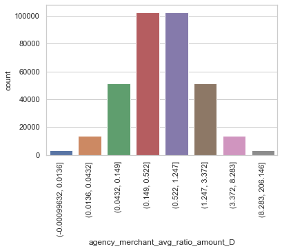

```python
import matplotlib.pyplot as plt
plt.figure(figsize=(6,4))
g = sns.countplot(x="agency_merchant_avg_ratio_amount_D", data=train1)
g.set_xticklabels(g.get_xticklabels(), rotation=90)
```

- The bar on the most right side is the 1% anomalies.
- The 1% anomalies are those transactions with ratios greater than 8.283. It means these transactions have amount at least 8 times the average spending.

We also have to create features for the test set.

```python
# create average spending group by agency and merchant category
stat_by_agency = test.groupby(['Agency_Name', 'Merchant_Category'])['Amount'].mean()
stat_by_agency = pd.DataFrame(stat_by_agency)
stat_by_agency.columns = ['AVG_amount']
# add the new feature average spending to the dataset
test1 = pd.merge(test, stat_by_agency, how='left', on=['Agency_Name', 'Merchant_Category'])
# Feature 1: ratio of amount spending and avergae spending by Agency_Name and merchant category
test1['agency_merchant_avg_ratio_amount'] = np.where(test1['AVG_amount']==0,0, test1['Amount'] / test1['AVG_amount'])
test1['agency_merchant_avg_ratio_amount'].describe()
```

```
count    85586.000000
mean         1.000000
std          1.970476
min          0.000009
25%          0.201712
50%          0.557853
75%          1.056842
max         95.738413
Name: agency_merchant_avg_ratio_amount, dtype: float64
```

### 3.2 Feature 2: The ratio to the median amount

Back to Table of Contents

Notice the only difference to the above code is "median".

```python
# create average spending group by agency and merchant category
stat_by_agency = train.groupby(['Agency_Name', 'Merchant_Category'])['Amount'].median()
stat_by_agency = pd.DataFrame(stat_by_agency)
stat_by_agency.columns = ['Median_amount']

# add the new feature average spending to the dataset
train2 = pd.merge(train, stat_by_agency, how='left', on=['Agency_Name', 'Merchant_Category'])
# Feature 2: ratio of amount spending and median spending by merchant category
train2['agency_merchant_median_ratio_amount'] = np.where(train2['Median_amount']==0,0, train2['Amount'] / train2['Median_amount'])
train2['agency_merchant_median_ratio_amount'].describe()

# cut by percentile for plotting
var = 'agency_merchant_median_ratio_amount'
binned_var = var + '_D'
percentile = [0,0.01,0.05,0.2,0.5,0.8,0.95,0.99,1]
train2[binned_var] = pd.qcut(train2[var],percentile)
```

```
[Text(0, 0, '(-0.0009889, 0.0422]'),
```

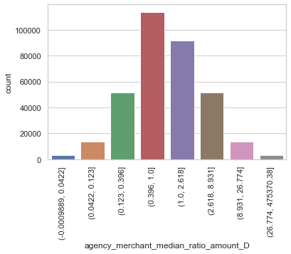

```python
import matplotlib.pyplot as plt
plt.figure(figsize=(6,4))
g = sns.countplot(x="agency_merchant_median_ratio_amount_D", data=train2)
g.set_xticklabels(g.get_xticklabels(), rotation=90)
```

- The above histogram is different from the one we created in the first feature.
- Transactions with a ratio greater than 26 will be detected as anomaly.
- Take a look at them.

```python
train2[train2['agency_merchant_median_ratio_amount']>26].head()
```

|  | Year_Month | Agency_Number | Agency_Name | Cardholder_Last_Name | Cardholder_First_Initial | Description | Amount | Vendor | Transaction_Date | Posted_Date | Merchant_Category | Year | Month | Week_Number | Day_of_Week | Median_amount | agency_merchant_median_ratio_amount | agency_merchant_median_ratio_amount_D |
| --- | --- | --- | --- | --- | --- | --- | --- | --- | --- | --- | --- | --- | --- | --- | --- | --- | --- | --- |
| 40 | 2013-10-01 | 92200 | OKLAHOMA HOUSING FINANCE AGENCY | Schweitzer | D | GENERAL PURCHASE | 1930.50 | CLAMPITT PAPER OKLAHOMA | 2013-10-03 | 2013-10-04 | STATIONERY, OFFICE SUPPLIES, PRINTING AND WRIT... | 2013 | 10 | 40 | Thursday | 58.32 | 33.101852 | (26.774, 475370.38] |
| 280 | 2014-06-01 | 1000 | OKLAHOMA STATE UNIVERSITY | Cash | T | GENERAL PURCHASE | 2500.00 | CHUCK BOLAND MEDICAL SALE | 2014-06-23 | 2014-06-24 | MISCELLANEOUS AND SPECIALTY RETAIL STORES | 2014 | 6 | 26 | Monday | 78.37 | 31.899962 | (26.774, 475370.38] |
| 425 | 2014-05-01 | 77000 | UNIV. OF OKLA. HEALTH SCIENCES CENTER | ROYAL | L | GENERAL PURCHASE | 40573.75 | BMG LABTECH, INC. | 2014-05-28 | 2014-05-29 | COMMERCIAL EQUIPMENT, NOT ELSEWHERE CLASSIFIED | 2014 | 5 | 22 | Wednesday | 278.11 | 145.891014 | (26.774, 475370.38] |
| 488 | 2014-06-01 | 40000 | OFFICE OF JUVENILE AFFAIRS | Andrews | K | GENERAL PURCHASE | 1704.56 | STAPLES ACCOUN00687632 | 2014-06-12 | 2014-06-16 | STATIONERY, OFFICE SUPPLIES, PRINTING AND WRIT... | 2014 | 6 | 24 | Thursday | 52.80 | 32.283333 | (26.774, 475370.38] |
| 560 | 2013-08-01 | 1000 | OKLAHOMA STATE UNIVERSITY | Sherrill | C | GENERAL PURCHASE | 4517.50 | HELENA CHEM CO 24122 | 2013-08-05 | 2013-08-06 | CHEMICALS AND ALLIED PRODUCTS NOT ELSEWHERE CL... | 2013 | 8 | 32 | Monday | 66.27 | 68.168100 | (26.774, 475370.38] |

Create features for the test set

```python
# create average spending group by agency and merchant category
stat_by_agency = test.groupby(['Agency_Name', 'Merchant_Category'])['Amount'].median()
stat_by_agency = pd.DataFrame(stat_by_agency)
stat_by_agency.columns = ['Median_amount']

# add the new feature average spending to the dataset
test2 = pd.merge(test, stat_by_agency, how='left', on=['Agency_Name', 'Merchant_Category'])
# Feature 2: ratio of amount spending and median spending by merchant category
test2['agency_merchant_median_ratio_amount'] = np.where(test2['Median_amount']==0,0, test2['Amount'] / test2['Median_amount'])
test2['agency_merchant_median_ratio_amount'].describe()
```

```
count    85586.000000
mean         2.628443
std         13.289031
min          0.000028
25%          0.506202
50%          1.000000
75%          1.986793
max       2162.359693
Name: agency_merchant_median_ratio_amount, dtype: float64
```

### 3.3 Feature 3: The ratio to Average amount spending by month

Back to Table of Contents

My thought process:

- We know a fraud transaction would have a relatively high amount of spending in a certain time interval. Therefore, we can compare the amount of each transaction to the average spending of that month to detect anomaly.
- Also, the comparison here happened at "Agency_Name" and "Merchant_Category" level.

```python
# create average spending group by agency, merchant category, and month
stat_by_month = train.groupby(['Agency_Name', 'Merchant_Category','Month'])['Amount'].mean()
stat_by_month = pd.DataFrame(stat_by_month)
stat_by_month.columns = ['AVG_amount']
stat_by_month
```

| Agency_Name | Merchant_Category | Month | AVG_amount |
| --- | --- | --- | --- |
| ARDMORE HIGHER EDUCATION CENTER | BUSINESS SERVICES NOT ELSEWHERE CLASSIFIED | 11 | 115.1200 |
|  | CATALOG MERCHANTS | 10 | 334.5400 |
|  |  | 11 | 116.5050 |
|  | COMPUTER NETWORK/INFORMATION SERVICES | 10 | 18.3400 |
|  | DRUG STORES AND PHARMACIES | 12 | 153.4500 |
| ... | ... | ... | ... |
| WORKERS COMPENSATION COURT | CATALOG MERCHANTS | 1 | 50.0000 |
|  | COMPUTERS, COMPUTER PERIPHERAL EQUIPMENT, SOFTWARE | 1 | 217.0000 |
|  |  | 7 | 86.2900 |
|  |  | 8 | 123.8675 |
|  | TELECOMMUNICATION EQUIPMENT AND TELEPHONE SALES | 1 | 324.7100 |

36133 rows × 1 columns

```python
# add the new feature average spending to the dataset
train3 = pd.merge(train, stat_by_month, how='left', on=['Agency_Name', 'Merchant_Category','Month'])
# Feature 3: The ratio to Average amount spent per transaction of each month
train3['agency_merchant_month_avg_ratio_amount'] = np.where(train3['AVG_amount']==0,0, train3['Amount'] / train3['AVG_amount'])
train3['agency_merchant_month_avg_ratio_amount'].describe()
```

```
count    342341.000000
mean          1.000000
std           1.721705
min           0.000003
25%           0.223034
50%           0.612795
75%           1.072614
max         101.982061
Name: agency_merchant_month_avg_ratio_amount, dtype: float64
```

```python
# cut by percentile for plotting
var = 'agency_merchant_month_avg_ratio_amount'
binned_var = var + '_D'
percentile = [0,0.01,0.05,0.2,0.5,0.8,0.95,0.99,1]
train3[binned_var] = pd.qcut( train3[var],percentile)
train3[['agency_merchant_month_avg_ratio_amount_D']]
```

|  | agency_merchant_month_avg_ratio_amount_D |
| --- | --- |
| 0 | (0.0483, 0.171] |
| 1 | (0.613, 1.276] |
| 2 | (0.0483, 0.171] |
| 3 | (0.171, 0.613] |
| 4 | (0.0483, 0.171] |
| ... | ... |
| 342336 | (0.171, 0.613] |
| 342337 | (0.171, 0.613] |
| 342338 | (0.0483, 0.171] |
| 342339 | (1.276, 3.201] |
| 342340 | (0.613, 1.276] |

342341 rows × 1 columns

My thought process:

- We performed the percentile cutting like we did in previous features.
- A high ratio may be a fradulent transaction, but not necessarily.

```
[Text(0, 0, '(-0.0009968, 0.0148]'),
```

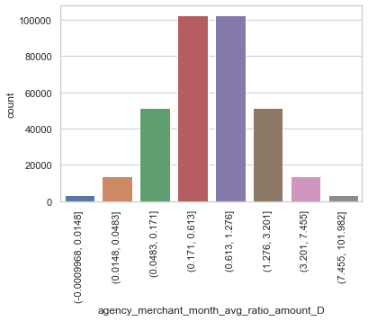

```python
import matplotlib.pyplot as plt
plt.figure(figsize=(6,4))
g = sns.countplot(x="agency_merchant_month_avg_ratio_amount_D", data=train3)
g.set_xticklabels(g.get_xticklabels(), rotation=90)
```

Thought process:

- Now we have identified extreme spending compared to the same merchant category of each month.
- The 1% anomalies are those transactions at the most right side of the graph. These transactions have amount at least 7 times the average spending.
- Some transactions have an unreasonable high ratio. This problem is caused by we have a transaction whose amount is very close to zero. When it becomes the denomitor in a ratio, the ratio become a large value. A solution here is to use median instead of mean.
- Take a look of them.

```python
train3.sort_values('agency_merchant_month_avg_ratio_amount',ascending=False).head(5)
```

|  | Year_Month | Agency_Number | Agency_Name | Cardholder_Last_Name | Cardholder_First_Initial | Description | Amount | Vendor | Transaction_Date | Posted_Date | Merchant_Category | Year | Month | Week_Number | Day_of_Week | AVG_amount | agency_merchant_month_avg_ratio_amount | agency_merchant_month_avg_ratio_amount_D |
| --- | --- | --- | --- | --- | --- | --- | --- | --- | --- | --- | --- | --- | --- | --- | --- | --- | --- | --- |
| 44479 | 2013-08-01 | 13100 | DEPARTMENT OF CORRECTIONS | Bowlin | C | JDCC CHILLER PROJECT- (2) EA | 96190.38 | WW GRAINGER | 2013-08-28 | 2013-08-30 | INDUSTRIAL SUPPLIES NOT ELSEWHERE CLASSIFIED | 2013 | 8 | 35 | Wednesday | 943.208828 | 101.982061 | (7.455, 101.982] |
| 273250 | 2013-12-01 | 76000 | UNIVERSITY OF OKLAHOMA | SMALL | D | RDTPYMT90420395 PCE | 4452.21 | FEDEX 90420395 | 2013-12-06 | 2013-12-09 | COURIER SERVICES-AIR AND GROUND,AND FREIGHT FO... | 2013 | 12 | 49 | Friday | 47.417865 | 93.893092 | (7.455, 101.982] |
| 114082 | 2013-08-01 | 34500 | DEPARTMENT OF TRANSPORTATION | HUENERGARDT | S | BATTERY EA\|BATTERY EA\|AIR FILTER EA\|AIR FILTER... | 47304.42 | OREILLY AUTO 00003145 | 2013-08-16 | 2013-08-19 | AUTOMOTIVE PARTS AND ACCESSORIES STORES | 2013 | 8 | 33 | Friday | 560.468268 | 84.401603 | (7.455, 101.982] |
| 83010 | 2013-10-01 | 13100 | DEPARTMENT OF CORRECTIONS | Saltzman | D | mobile Sand Blasting trai EA | 55000.00 | WW GRAINGER | 2013-10-16 | 2013-10-18 | INDUSTRIAL SUPPLIES NOT ELSEWHERE CLASSIFIED | 2013 | 10 | 42 | Wednesday | 675.233451 | 81.453311 | (7.455, 101.982] |
| 129016 | 2013-08-01 | 77000 | UNIV. OF OKLA. HEALTH SCIENCES CENTER | MECHAM | S | GENERAL PURCHASE | 61580.29 | THE ARGEN CORPORATION | 2013-08-05 | 2013-08-06 | DENTAL/LABORATORY/MEDICAL/OPHTHALMIC HOSP EQIP... | 2013 | 8 | 32 | Monday | 756.797425 | 81.369582 | (7.455, 101.982] |

Create features for test set

```python
# create average spending group by agency, merchant category, and month
stat_by_month = test.groupby(['Agency_Name', 'Merchant_Category','Month'])['Amount'].mean()
stat_by_month = pd.DataFrame(stat_by_month)
stat_by_month.columns = ['AVG_amount']
# add the new feature average spending to the dataset
test3 = pd.merge(test, stat_by_month, how='left', on=['Agency_Name', 'Merchant_Category','Month'])
# Feature 3: The ratio to Average amount spent per transaction of each month
test3['agency_merchant_month_avg_ratio_amount'] = np.where(test3['AVG_amount']==0,0, test3['Amount'] / test3['AVG_amount'])
test3['agency_merchant_month_avg_ratio_amount'].describe()
```

```
count    85586.000000
mean         1.000000
std          1.379727
min          0.000009
25%          0.268661
50%          0.769512
75%          1.076923
max         48.793901
Name: agency_merchant_month_avg_ratio_amount, dtype: float64
```

### 3.4 Feature 4: The ratio to Average amount spending by week number

Back to Table of Contents

My thought process:

- We know a fraud transaction would have a relatively high amount of spending in a certain time interval. Like we aggregate by 'month' in the previous feature, We can compare the amount of each transaction to the average spending of week number to detect anomaly.
- Also, the comparison here happened at "Agency_Name" and "Merchant_Category" level.

```python
# create average spending group by agency, merchant category, and month
stat_by_week = train.groupby(['Agency_Name', 'Merchant_Category','Week_Number'])['Amount'].mean()
stat_by_week = pd.DataFrame(stat_by_week)
stat_by_week.columns = ['AVG_amount']
stat_by_week
```

| Agency_Name | Merchant_Category | Week_Number | AVG_amount |
| --- | --- | --- | --- |
| ARDMORE HIGHER EDUCATION CENTER | BUSINESS SERVICES NOT ELSEWHERE CLASSIFIED | 45 | 115.120 |
|  | CATALOG MERCHANTS | 41 | 334.540 |
|  |  | 48 | 116.505 |
|  | COMPUTER NETWORK/INFORMATION SERVICES | 41 | 18.340 |
|  | DRUG STORES AND PHARMACIES | 49 | 153.450 |
| ... | ... | ... | ... |
| WORKERS COMPENSATION COURT | COMPUTERS, COMPUTER PERIPHERAL EQUIPMENT, SOFTWARE | 30 | 86.290 |
|  |  | 31 | 217.000 |
|  |  | 33 | 83.520 |
|  |  | 35 | 97.475 |
|  | TELECOMMUNICATION EQUIPMENT AND TELEPHONE SALES | 5 | 324.710 |

73439 rows × 1 columns

```python
# add the new feature average spending to the dataset
train4 = pd.merge(train, stat_by_week, how='left', on=['Agency_Name', 'Merchant_Category','Week_Number'])
# Feature 4: The ratio to Average amount spent of week number
train4['agency_merchant_week_avg_ratio_amount'] = np.where(train4['AVG_amount']==0,0, train4['Amount'] / train4['AVG_amount'])
train4['agency_merchant_week_avg_ratio_amount'].describe()
```

```
count    342341.000000
mean          1.000000
std           1.354813
min           0.000003
25%           0.278149
50%           0.777082
75%           1.080942
max          65.827178
Name: agency_merchant_week_avg_ratio_amount, dtype: float64
```

```
[Text(0, 0, '(-0.00099668, 0.0168]'),
```

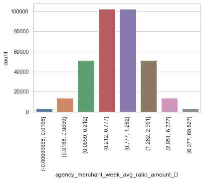

```python
# cut by percentile for plotting
var = 'agency_merchant_week_avg_ratio_amount'
binned_var = var + '_D'
percentile = [0,0.01,0.05,0.2,0.5,0.8,0.95,0.99,1]
train4[binned_var] = pd.qcut( train4[var],percentile)
train4[['agency_merchant_week_avg_ratio_amount_D']]

import matplotlib.pyplot as plt
plt.figure(figsize=(6,4))
g = sns.countplot(x="agency_merchant_week_avg_ratio_amount_D", data=train4)
g.set_xticklabels(g.get_xticklabels(), rotation=90)
```

Create features for test set

```python
stat_by_week = test.groupby(['Agency_Name', 'Merchant_Category','Week_Number'])['Amount'].mean()
stat_by_week = pd.DataFrame(stat_by_week)
stat_by_week.columns = ['AVG_amount']
test4 = pd.merge(test, stat_by_week, how='left', on=['Agency_Name', 'Merchant_Category','Week_Number'])
# Feature 4: The ratio to Average amount spent of week number
test4['agency_merchant_week_avg_ratio_amount'] = np.where(test4['AVG_amount']==0,0, test4['Amount'] / test4['AVG_amount'])
test4['agency_merchant_week_avg_ratio_amount'].describe()
```

```
count    85586.000000
mean         1.000000
std          0.974129
min          0.000003
25%          0.402811
50%          1.000000
75%          1.037887
max         20.625642
Name: agency_merchant_week_avg_ratio_amount, dtype: float64
```

### 3.5 Feature 5: The ratio to average amount spending of day of week

Back to Table of Contents

My thought process:

- If a credit card was compromised, we can assume that amount of transaction in a particular day can be extremely high.
- Therefore, we can compare each transaction's amount to the average amount of each day in a week. For example, if a transaction happened at Monday, we can compare its amount to the average Monday transaction amount. By choosing day of week as a benchmark, we are able to detect anomalies.

```python
# create average spending group by agency, merchant category, and month
stat_by_dayofweek = train.groupby(['Agency_Name', 'Merchant_Category','Day_of_Week'])['Amount'].mean()
stat_by_dayofweek = pd.DataFrame(stat_by_dayofweek)
stat_by_dayofweek.columns = ['AVG_amount']
stat_by_dayofweek
```

| Agency_Name | Merchant_Category | Day_of_Week | AVG_amount |
| --- | --- | --- | --- |
| ARDMORE HIGHER EDUCATION CENTER | BUSINESS SERVICES NOT ELSEWHERE CLASSIFIED | Friday | 115.12 |
|  | CATALOG MERCHANTS | Monday | 334.54 |
|  |  | Thursday | 194.85 |
|  |  | Wednesday | 38.16 |
|  | COMPUTER NETWORK/INFORMATION SERVICES | Tuesday | 18.34 |
| ... | ... | ... | ... |
| WORKERS COMPENSATION COURT | CATALOG MERCHANTS | Wednesday | 50.00 |
|  | COMPUTERS, COMPUTER PERIPHERAL EQUIPMENT, SOFTWARE | Friday | 150.26 |
|  |  | Tuesday | 152.00 |
|  |  | Wednesday | 93.51 |
|  | TELECOMMUNICATION EQUIPMENT AND TELEPHONE SALES | Monday | 324.71 |

24914 rows × 1 columns

```python
# add the new feature average spending to the dataset
train5 = pd.merge(train, stat_by_dayofweek, how='left', on=['Agency_Name', 'Merchant_Category','Day_of_Week'])
# Feature 5: The ratio to Average amount spent of day of week
train5['agency_merchant_dayofweek_avg_ratio_amount'] = np.where(train5['AVG_amount']==0,0, train5['Amount'] / train5['AVG_amount'])
train5['agency_merchant_dayofweek_avg_ratio_amount'].describe()
```

```
count    342341.000000
mean          1.000000
std           1.901330
min           0.000002
25%           0.211348
50%           0.579642
75%           1.063426
max         135.886348
Name: agency_merchant_dayofweek_avg_ratio_amount, dtype: float64
```

```
[Text(0, 0, '(-0.00099813, 0.0144]'),
```

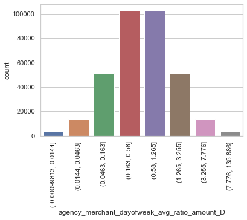

```python
# cut by percentile for plotting
var = 'agency_merchant_dayofweek_avg_ratio_amount'
binned_var = var + '_D'
percentile = [0,0.01,0.05,0.2,0.5,0.8,0.95,0.99,1]
train5[binned_var] = pd.qcut( train5[var],percentile)
train5[['agency_merchant_dayofweek_avg_ratio_amount']]

import matplotlib.pyplot as plt
plt.figure(figsize=(6,4))
g = sns.countplot(x="agency_merchant_dayofweek_avg_ratio_amount_D", data=train5)
g.set_xticklabels(g.get_xticklabels(), rotation=90)
```

Thought process:

- Transactions with extremely high ratio can be treated as an anomaly.
- The 1% anomalies have amount at least 7 times the average spending on certain day of week.
- Take a look of them.

```python
train5[train5['agency_merchant_dayofweek_avg_ratio_amount']>7].head(5)
```

|  | Year_Month | Agency_Number | Agency_Name | Cardholder_Last_Name | Cardholder_First_Initial | Description | Amount | Vendor | Transaction_Date | Posted_Date | Merchant_Category | Year | Month | Week_Number | Day_of_Week | AVG_amount | agency_merchant_dayofweek_avg_ratio_amount | agency_merchant_dayofweek_avg_ratio_amount_D |
| --- | --- | --- | --- | --- | --- | --- | --- | --- | --- | --- | --- | --- | --- | --- | --- | --- | --- | --- |
| 40 | 2013-10-01 | 92200 | OKLAHOMA HOUSING FINANCE AGENCY | Schweitzer | D | GENERAL PURCHASE | 1930.50 | CLAMPITT PAPER OKLAHOMA | 2013-10-03 | 2013-10-04 | STATIONERY, OFFICE SUPPLIES, PRINTING AND WRIT... | 2013 | 10 | 40 | Thursday | 171.372931 | 11.264906 | (7.776, 135.886] |
| 103 | 2014-06-01 | 32000 | DEPARTMENT OF WILDLIFE CONSERVATION | Baker | W | KBLT 93PC SKT SET EA\|7-1/4-IN NEXT GEN CIRCSAW... | 1578.84 | LOWES #01749 | 2014-06-25 | 2014-06-26 | HOME SUPPLY WAREHOUSE STORES | 2014 | 6 | 26 | Wednesday | 162.051400 | 9.742835 | (7.776, 135.886] |
| 104 | 2014-03-01 | 13100 | DEPARTMENT OF CORRECTIONS | Devine | L | BOOST GLUC CNTL CHOC 8OZ CS\|NEPRO VAN 8OZ CAN ... | 4188.84 | MCKESSON MEDICAL SUPPLY | 2014-03-08 | 2014-03-10 | DENTAL/LABORATORY/MEDICAL/OPHTHALMIC HOSP EQIP... | 2014 | 3 | 10 | Saturday | 567.438243 | 7.382019 | (3.255, 7.776] |
| 177 | 2014-02-01 | 76000 | UNIVERSITY OF OKLAHOMA | ECKART | A | Elmo MO-1 Visual Presenter PCE | 747.78 | AMAZON MKTPLACE PMTS | 2014-02-26 | 2014-02-27 | BOOK STORES | 2014 | 2 | 9 | Wednesday | 104.074702 | 7.185031 | (3.255, 7.776] |
| 180 | 2013-09-01 | 1000 | OKLAHOMA STATE UNIVERSITY | Bowers | R | GENERAL PURCHASE | 1532.00 | LOCKE SUPPLY - STILLWATER | 2013-09-10 | 2013-09-12 | HARDWARE STORES | 2013 | 9 | 37 | Tuesday | 166.504730 | 9.200940 | (7.776, 135.886] |

Create features for test set

```python
# create average spending group by agency, merchant category, and month
stat_by_dayofweek = test.groupby(['Agency_Name', 'Merchant_Category','Day_of_Week'])['Amount'].mean()
stat_by_dayofweek = pd.DataFrame(stat_by_dayofweek)
stat_by_dayofweek.columns = ['AVG_amount']
# add the new feature average spending to the dataset
test5 = pd.merge(test, stat_by_dayofweek, how='left', on=['Agency_Name', 'Merchant_Category','Day_of_Week'])
# Feature 5: The ratio to Average amount spent of day of week
test5['agency_merchant_dayofweek_avg_ratio_amount'] = np.where(test5['AVG_amount']==0,0, test5['Amount'] / test5['AVG_amount'])
test5['agency_merchant_dayofweek_avg_ratio_amount'].describe()
```

```
count    85586.000000
mean         1.000000
std          1.514377
min          0.000011
25%          0.243164
50%          0.680644
75%          1.078289
max         58.969154
Name: agency_merchant_dayofweek_avg_ratio_amount, dtype: float64
```

### 3.6 Feature 6: The ratio to Average amount spent per day over the past 30 days

Back to Table of Contents

Thought process:

- The intuition here is that because one person's behavior might change along with time, latest 30 days transactions are more important than previous several months transactions. A latest transaction could reflect a cardholder's behavior more accurately.
- By comparing transaction amount to the averaged amount in the past 30 days, we are able to detect anomalies.
- On "Agency_name" and "merchant_category" level, we compare each transaction's amount to the average amount spent per day over the past 30 days.

```python
# Calculate the daily average spending at agency and merchant level.
stat_date = train.groupby(['Agency_Name','Merchant_Category','Transaction_Date'])["Amount"].mean()
stat_date = pd.DataFrame(stat_date)

stat_date = stat_date.reset_index()

# Sort within two groups
stat_date = stat_date.sort_values(by = ['Agency_Name','Merchant_Category','Transaction_Date'],ascending=True).reset_index(drop=True)
stat_date.head(5)
```

|  | Agency_Name | Merchant_Category | Transaction_Date | Amount |
| --- | --- | --- | --- | --- |
| 0 | ARDMORE HIGHER EDUCATION CENTER | BUSINESS SERVICES NOT ELSEWHERE CLASSIFIED | 2013-11-08 | 115.12 |
| 1 | ARDMORE HIGHER EDUCATION CENTER | CATALOG MERCHANTS | 2013-10-07 | 334.54 |
| 2 | ARDMORE HIGHER EDUCATION CENTER | CATALOG MERCHANTS | 2013-11-27 | 38.16 |
| 3 | ARDMORE HIGHER EDUCATION CENTER | CATALOG MERCHANTS | 2013-11-28 | 194.85 |
| 4 | ARDMORE HIGHER EDUCATION CENTER | COMPUTER NETWORK/INFORMATION SERVICES | 2013-10-08 | 18.34 |

We have the average transaction amount of each Transaction_Date. Next, we will calculate the past 30 days' average transaction amount of all transaction date.

```python
# Set transaction_date to be index, and we can perform rolling function without error
stat_date = stat_date.set_index('Transaction_Date')

# Average 30 days' spending amount for each transaction date
stat_date_roll30d = stat_date.groupby(['Agency_Name','Merchant_Category'])['Amount'].rolling('30D').mean()
stat_date_roll30d = pd.DataFrame(stat_date_roll30d)
stat_date_roll30d = stat_date_roll30d.rename(columns={"Amount": "average_amount"})
stat_date_roll30d.head(5)
```

| Agency_Name | Merchant_Category | Transaction_Date | average_amount |
| --- | --- | --- | --- |
| ARDMORE HIGHER EDUCATION CENTER | BUSINESS SERVICES NOT ELSEWHERE CLASSIFIED | 2013-11-08 | 115.120 |
|  | CATALOG MERCHANTS | 2013-10-07 | 334.540 |
|  |  | 2013-11-27 | 38.160 |
|  |  | 2013-11-28 | 116.505 |
|  | COMPUTER NETWORK/INFORMATION SERVICES | 2013-10-08 | 18.340 |

Next, we can merge two data tables and compare each transaction amount to the average amount of past 30 days at 'Agency_Name', 'Merchant_Category', and 'Transaction_Date' level.

```python
# add the new feature average spending to the dataset
train6 = pd.merge(train, stat_date_roll30d, how='left', on=['Agency_Name', 'Merchant_Category','Transaction_Date'])
# Feature 6: ratio of amount spending and 30 days' avergae spending by Agency_Name', 'Merchant_Category','Transaction_Date
train6['agency_merchant_30days_roll_ratio'] = np.where(train6['average_amount']==0,0, train6['Amount'] / train6['average_amount'])
train6['agency_merchant_30days_roll_ratio'].describe()
```

```
count    342341.000000
mean          1.004342
std           1.752934
min           0.000004
25%           0.220769
50%           0.616625
75%           1.076244
max         103.704834
Name: agency_merchant_30days_roll_ratio, dtype: float64
```

```
[Text(0, 0, '(-0.00099601, 0.0145]'),
```

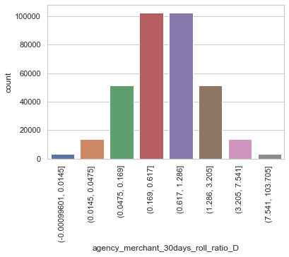

```python
# cut by percentile for plotting
var = 'agency_merchant_30days_roll_ratio'
binned_var = var + '_D'
percentile = [0,0.01,0.05,0.2,0.5,0.8,0.95,0.99,1]
train6[binned_var] = pd.qcut(train6[var],percentile)
train6[['agency_merchant_30days_roll_ratio']]

import matplotlib.pyplot as plt
plt.figure(figsize=(6,4))
g = sns.countplot(x="agency_merchant_30days_roll_ratio_D", data=train6)
g.set_xticklabels(g.get_xticklabels(), rotation=90)
```

Thought process:

- Now we have detected abnormal transactions using 'agency_merchant_30days_roll_ratio'.
- The 1% anomalies have amount at least 7 times the average past 30 days' spending.
- How many transactions have ratios greater than 10?
- Take a look of them.

```python
train6[train6['agency_merchant_30days_roll_ratio']>10].head(5)
```

|  | Year_Month | Agency_Number | Agency_Name | Cardholder_Last_Name | Cardholder_First_Initial | Description | Amount | Vendor | Transaction_Date | Posted_Date | Merchant_Category | Year | Month | Week_Number | Day_of_Week | average_amount | agency_merchant_30days_roll_ratio | agency_merchant_30days_roll_ratio_D |
| --- | --- | --- | --- | --- | --- | --- | --- | --- | --- | --- | --- | --- | --- | --- | --- | --- | --- | --- |
| 104 | 2014-03-01 | 13100 | DEPARTMENT OF CORRECTIONS | Devine | L | BOOST GLUC CNTL CHOC 8OZ CS\|NEPRO VAN 8OZ CAN ... | 4188.84 | MCKESSON MEDICAL SUPPLY | 2014-03-08 | 2014-03-10 | DENTAL/LABORATORY/MEDICAL/OPHTHALMIC HOSP EQIP... | 2014 | 3 | 10 | Saturday | 387.630232 | 10.806278 | (7.541, 103.705] |
| 425 | 2014-05-01 | 77000 | UNIV. OF OKLA. HEALTH SCIENCES CENTER | ROYAL | L | GENERAL PURCHASE | 40573.75 | BMG LABTECH, INC. | 2014-05-28 | 2014-05-29 | COMMERCIAL EQUIPMENT, NOT ELSEWHERE CLASSIFIED | 2014 | 5 | 22 | Wednesday | 1262.986719 | 32.125239 | (7.541, 103.705] |
| 560 | 2013-08-01 | 1000 | OKLAHOMA STATE UNIVERSITY | Sherrill | C | GENERAL PURCHASE | 4517.50 | HELENA CHEM CO 24122 | 2013-08-05 | 2013-08-06 | CHEMICALS AND ALLIED PRODUCTS NOT ELSEWHERE CL... | 2013 | 8 | 32 | Monday | 334.230200 | 13.516134 | (7.541, 103.705] |
| 767 | 2014-04-01 | 1000 | OKLAHOMA STATE UNIVERSITY | Green | S | Designers Edge L-15 Work L PCE\|Pack of 2 LP-E6... | 3128.30 | AMAZON MKTPLACE PMTS | 2014-04-10 | 2014-04-11 | BOOK STORES | 2014 | 4 | 15 | Thursday | 160.748274 | 19.460862 | (7.541, 103.705] |
| 1190 | 2014-01-01 | 77000 | UNIV. OF OKLA. HEALTH SCIENCES CENTER | KOUHDARI | P | Samsung Series 9 NP900X3E- PCE | 1201.77 | AMAZON MKTPLACE PMTS | 2014-01-15 | 2014-01-15 | BOOK STORES | 2014 | 1 | 3 | Wednesday | 117.330951 | 10.242566 | (7.541, 103.705] |

Create features for test set

```python
stat_date = test.groupby(['Agency_Name','Merchant_Category','Transaction_Date'])["Amount"].mean()
stat_date = pd.DataFrame(stat_date)

stat_date = stat_date.reset_index()

# Sort within two groups
stat_date = stat_date.sort_values(by = ['Agency_Name','Merchant_Category','Transaction_Date'],ascending=True).reset_index(drop=True)
stat_date = stat_date.set_index('Transaction_Date')

# Average 30 days' spending amount for each transaction date
stat_date_roll30d = stat_date.groupby(['Agency_Name','Merchant_Category'])['Amount'].rolling('30D').mean()
stat_date_roll30d = pd.DataFrame(stat_date_roll30d)
stat_date_roll30d = stat_date_roll30d.rename(columns={"Amount": "average_amount"})
# add the new feature average spending to the dataset
test6 = pd.merge(test, stat_date_roll30d, how='left', on=['Agency_Name', 'Merchant_Category','Transaction_Date'])
# Feature 6: ratio of amount spending and 30 days' avergae spending by Agency_Name', 'Merchant_Category','Transaction_Date
test6['agency_merchant_30days_roll_ratio'] = np.where(test6['average_amount']==0,0, test6['Amount'] / test6['average_amount'])
test6['agency_merchant_30days_roll_ratio'].describe()
```

```
count    85586.000000
mean         1.010051
std          1.429929
min          0.000026
25%          0.270857
50%          0.793634
75%          1.080824
max         92.955892
Name: agency_merchant_30days_roll_ratio, dtype: float64
```

### 3.7 Feature 7: The ratio to Average amount spent over the past 90 days

Back to Table of Contents

Thought process:

- Like what we did in the last feature, we replace the past 30 days with 90 days. We hope a longer time interval can help us capture more anomalies.
- On "Agency_name" and "merchant_category" level, we compare each transaction's amount to the average amount spent per day over the past 90 days.

```python
# Calculate the daily average spending at agency and merchant level.
stat_date = train.groupby(['Agency_Name','Merchant_Category','Transaction_Date'])["Amount"].mean()
stat_date = pd.DataFrame(stat_date)

stat_date = stat_date.reset_index()

stat_date = stat_date.sort_values(by = ['Agency_Name','Merchant_Category','Transaction_Date'],ascending=True).reset_index(drop=True)
```

```python
# Set transaction_date to be index, and we can perform rolling function without error
stat_date = stat_date.set_index('Transaction_Date')

# Average 30 days' spending amount for each transaction date
stat_date_roll90d = stat_date.groupby(['Agency_Name','Merchant_Category'])['Amount'].rolling('90D').mean()
stat_date_roll90d = pd.DataFrame(stat_date_roll90d)
stat_date_roll90d = stat_date_roll90d.rename(columns={"Amount": "average_amount"})
stat_date_roll90d.head(5)
```

| Agency_Name | Merchant_Category | Transaction_Date | average_amount |
| --- | --- | --- | --- |
| ARDMORE HIGHER EDUCATION CENTER | BUSINESS SERVICES NOT ELSEWHERE CLASSIFIED | 2013-11-08 | 115.120000 |
|  | CATALOG MERCHANTS | 2013-10-07 | 334.540000 |
|  |  | 2013-11-27 | 186.350000 |
|  |  | 2013-11-28 | 189.183333 |
|  | COMPUTER NETWORK/INFORMATION SERVICES | 2013-10-08 | 18.340000 |

```python
# add the new feature average spending to the dataset
train7 = pd.merge(train, stat_date_roll90d, how='left', on=['Agency_Name', 'Merchant_Category','Transaction_Date'])
train7['agency_merchant_90days_roll_ratio'] = np.where(train7['average_amount']==0,0, train7['Amount'] / train7['average_amount'])
train7['agency_merchant_90days_roll_ratio'].describe()
```

```
count    342341.000000
mean          0.997890
std           1.909468
min           0.000002
25%           0.203341
50%           0.564576
75%           1.060611
max         146.245441
Name: agency_merchant_90days_roll_ratio, dtype: float64
```

```
[Text(0, 0, '(-0.00099786, 0.0141]'),
```

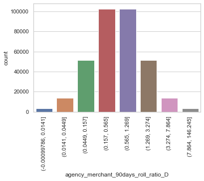

```python
# cut by percentile for plotting
var = 'agency_merchant_90days_roll_ratio'
binned_var = var + '_D'
percentile = [0,0.01,0.05,0.2,0.5,0.8,0.95,0.99,1]
train7[binned_var] = pd.qcut( train7[var],percentile)
train7[['agency_merchant_90days_roll_ratio']]

import matplotlib.pyplot as plt
plt.figure(figsize=(6,4))
g = sns.countplot(x="agency_merchant_90days_roll_ratio_D", data=train7)
g.set_xticklabels(g.get_xticklabels(), rotation=90)
```

- The 1% anomalies have amount at least 7 times the average 90 days' spending.

Create features for test set

```python
stat_date = test.groupby(['Agency_Name','Merchant_Category','Transaction_Date'])["Amount"].mean()
stat_date = pd.DataFrame(stat_date)

stat_date = stat_date.reset_index()

stat_date = stat_date.sort_values(by = ['Agency_Name','Merchant_Category','Transaction_Date'],ascending=True).reset_index(drop=True)

stat_date = stat_date.set_index('Transaction_Date')

# Average 30 days' spending amount for each transaction date
stat_date_roll90d = stat_date.groupby(['Agency_Name','Merchant_Category'])['Amount'].rolling('90D').mean()
stat_date_roll90d = pd.DataFrame(stat_date_roll90d)
stat_date_roll90d = stat_date_roll90d.rename(columns={"Amount": "average_amount"})

# add the new feature average spending to the dataset
test7 = pd.merge(test, stat_date_roll90d, how='left', on=['Agency_Name', 'Merchant_Category','Transaction_Date'])
test7['agency_merchant_90days_roll_ratio'] = np.where(test7['average_amount']==0,0, test7['Amount'] / test7['average_amount'])
test7['agency_merchant_90days_roll_ratio'].describe()
```

```
count    85586.000000
mean         1.003404
std          1.620418
min          0.000018
25%          0.234002
50%          0.665922
75%          1.076926
max        109.047329
Name: agency_merchant_90days_roll_ratio, dtype: float64
```

### 3.8 Feature 8: The ratio to number of transactions by month

Back to Table of Contents

My thought process:

- Because a fraudster want to exploit a credit card in a time period before the card is cancelled. If a credit card is compromised, the number of transaction of a fraudster would be extremely high compared to a normal cardholder's number of transactions.
- Therefore, we can compare each cardholder's total number of transactions on montly basis to the average number of transactions in that month. In this way, by choosing the average number of transactions as a benchmark, we are able to identify abnormal credit card usage.
- Remember, a cardholder with high number of transactions in one day cannot be viewed as anomly, we have to compare the a card holder's total number of transactions to the monthly average number of transactions in "Agency_Name" and "Merchant_category" level.

First, to get the averaged result, we need to calculate the total number of transactions in each month.

```python
# Calculate total number of transactions group by agency, merchant category, and month

# get row counts per group
stat_by_month = train.groupby(['Agency_Name', 'Merchant_Category','Month']).size()
stat_by_month = pd.DataFrame(stat_by_month)
stat_by_month.columns = ['Total_count']
stat_by_month = stat_by_month.reset_index()
stat_by_month.head(5)
```

|  | Agency_Name | Merchant_Category | Month | Total_count |
| --- | --- | --- | --- | --- |
| 0 | ARDMORE HIGHER EDUCATION CENTER | BUSINESS SERVICES NOT ELSEWHERE CLASSIFIED | 11 | 1 |
| 1 | ARDMORE HIGHER EDUCATION CENTER | CATALOG MERCHANTS | 10 | 1 |
| 2 | ARDMORE HIGHER EDUCATION CENTER | CATALOG MERCHANTS | 11 | 2 |
| 3 | ARDMORE HIGHER EDUCATION CENTER | COMPUTER NETWORK/INFORMATION SERVICES | 10 | 1 |
| 4 | ARDMORE HIGHER EDUCATION CENTER | DRUG STORES AND PHARMACIES | 12 | 1 |

Next, we calculate the number of card holders in each month.

To identify each cardholder, we create a new variable called 'Full_Name' by combining a card holder's first name and last name.

People have the same name could influence our aggregated result. This problem can be solved if the credit card company could provide us with unique identifier of each card.

To simplfy the problem, we do not consider the possibility of two people have the same name.

```python
# Number of card holders in each group
train["Full_Name"] = train["Cardholder_First_Initial"] + train["Cardholder_Last_Name"] # create new variable
# count number of unique names as number of card holders
number_cardholder_by_month = train.groupby(['Agency_Name', 'Merchant_Category','Month'])['Full_Name'].nunique()
number_cardholder_by_month = pd.DataFrame(number_cardholder_by_month)
number_cardholder_by_month.columns = ['Number_of_cardholders']
number_cardholder_by_month.head(5)
```

| Agency_Name | Merchant_Category | Month | Number_of_cardholders |
| --- | --- | --- | --- |
| ARDMORE HIGHER EDUCATION CENTER | BUSINESS SERVICES NOT ELSEWHERE CLASSIFIED | 11 | 1 |
|  | CATALOG MERCHANTS | 10 | 1 |
|  |  | 11 | 1 |
|  | COMPUTER NETWORK/INFORMATION SERVICES | 10 | 1 |
|  | DRUG STORES AND PHARMACIES | 12 | 1 |

Next, we merge the total number of monthly transactions table and the number of card holders table, and calculate the average number of transactions in each month.

```python
train8 = pd.merge(stat_by_month, number_cardholder_by_month, how='left', on=['Agency_Name', 'Merchant_Category','Month'])
train8['AVG_count'] = np.where(train8['Number_of_cardholders']==0,0, train8['Total_count'] / train8['Number_of_cardholders'])
```

Finally, we use groupby function to get the total number of transactions in each month for every card holder.

```python
c = train.groupby(['Cardholder_Last_Name','Cardholder_First_Initial','Agency_Name','Merchant_Category','Month']).size()
c = pd.DataFrame(c)
c.columns = ['Number_of_transactions']
c = c.reset_index()
c.head(5)
```

|  | Cardholder_Last_Name | Cardholder_First_Initial | Agency_Name | Merchant_Category | Month | Number_of_transactions |
| --- | --- | --- | --- | --- | --- | --- |
| 0 | 15000 | 1 | UNIV.OF SCIENCE & ARTS OF OK | OTHER FEES | 4 | 1 |
| 1 | 24100 | 2 | REDLANDS COMMUNITY COLLEGE | OTHER FEES | 1 | 1 |
| 2 | 24100 | 2 | REDLANDS COMMUNITY COLLEGE | OTHER FEES | 3 | 1 |
| 3 | 24100 | 2 | REDLANDS COMMUNITY COLLEGE | OTHER FEES | 7 | 2 |
| 4 | 24100 | 2 | REDLANDS COMMUNITY COLLEGE | OTHER FEES | 8 | 2 |

By merging two tables, we can compare the total number of transactions of each card holder to the monthly average number of transactions.

```python
# add the new feature average spending to the dataset
train8 = pd.merge(c, train8, how='left', on=['Agency_Name', 'Merchant_Category','Month'])

train8['agency_merchant_month_avg_ratio_count'] = np.where(train8['AVG_count']==0,0, train8['Number_of_transactions'] / train8['AVG_count'])
train8['agency_merchant_month_avg_ratio_count'].describe()
```

```
count    159523.000000
mean          1.000000
std           0.854287
min           0.007335
25%           0.602740
50%           0.864865
75%           1.000000
max          27.169811
Name: agency_merchant_month_avg_ratio_count, dtype: float64
```

```
[Text(0, 0, '(0.00633, 0.2]'),
```

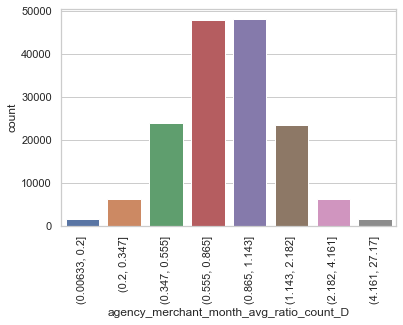

```python
# cut by percentile for plotting
var = 'agency_merchant_month_avg_ratio_count'
binned_var = var + '_D'
percentile = [0,0.01,0.05,0.2,0.5,0.8,0.95,0.99,1]
train8[binned_var] = pd.qcut( train8[var],percentile)
train8[['agency_merchant_month_avg_ratio_count']]

import matplotlib.pyplot as plt
plt.figure(figsize=(6,4))
g = sns.countplot(x="agency_merchant_month_avg_ratio_count_D", data=train8)
g.set_xticklabels(g.get_xticklabels(), rotation=90)
```

- From the above chart, we can see the 1% anomalies are those card holders whose ratios are greater than 4.16.
- It means these anomalies have number of transactions at least 4.16 times the average number of transactions in a monthly basis.
- Take a look at them.

```python
train8[train8['agency_merchant_month_avg_ratio_count']>4.39].head()
```

|  | Cardholder_Last_Name | Cardholder_First_Initial | Agency_Name | Merchant_Category | Month | Number_of_transactions | Total_count | Number_of_cardholders | AVG_count | agency_merchant_month_avg_ratio_count | agency_merchant_month_avg_ratio_count_D |
| --- | --- | --- | --- | --- | --- | --- | --- | --- | --- | --- | --- |
| 101 | ADAMS | K | UNIVERSITY OF OKLAHOMA | BUSINESS SERVICES NOT ELSEWHERE CLASSIFIED | 7 | 11 | 86 | 49 | 1.755102 | 6.267442 | (4.161, 27.17] |
| 233 | AGNELLI | M | UNIVERSITY OF OKLAHOMA | OTHER FEES | 3 | 10 | 66 | 32 | 2.062500 | 4.848485 | (4.161, 27.17] |
| 235 | AGNELLI | M | UNIVERSITY OF OKLAHOMA | OTHER FEES | 5 | 20 | 108 | 29 | 3.724138 | 5.370370 | (4.161, 27.17] |
| 310 | ALINGER | D | UNIVERSITY OF OKLAHOMA | AUTOMOTIVE PARTS AND ACCESSORIES STORES | 2 | 11 | 27 | 13 | 2.076923 | 5.296296 | (4.161, 27.17] |
| 356 | ALINGER | D | UNIVERSITY OF OKLAHOMA | HARDWARE STORES | 2 | 7 | 45 | 30 | 1.500000 | 4.666667 | (4.161, 27.17] |

Create features for the test set

```python
stat_by_month = test.groupby(['Agency_Name', 'Merchant_Category','Month']).size()
stat_by_month = pd.DataFrame(stat_by_month)
stat_by_month.columns = ['Total_count']
stat_by_month = stat_by_month.reset_index()

# Number of card holders in each group
test["Full_Name"] = test["Cardholder_First_Initial"] + test["Cardholder_Last_Name"] # create new variable
# count number of unique names as number of card holders
number_cardholder_by_month = test.groupby(['Agency_Name', 'Merchant_Category','Month'])['Full_Name'].nunique()
number_cardholder_by_month = pd.DataFrame(number_cardholder_by_month)
number_cardholder_by_month.columns = ['Number_of_cardholders']
test8 = pd.merge(stat_by_month, number_cardholder_by_month, how='left', on=['Agency_Name', 'Merchant_Category','Month'])
test8['AVG_count'] = np.where(test8['Number_of_cardholders']==0,0, test8['Total_count'] / test8['Number_of_cardholders'])
c = test.groupby(['Cardholder_Last_Name','Cardholder_First_Initial','Agency_Name','Merchant_Category','Month']).size()
c = pd.DataFrame(c)
c.columns = ['Number_of_transactions']
c = c.reset_index()
# add the new feature average spending to the dataset
test8 = pd.merge(c, test8, how='left', on=['Agency_Name', 'Merchant_Category','Month'])

test8['agency_merchant_month_avg_ratio_count'] = np.where(test8['AVG_count']==0,0, test8['Number_of_transactions'] / test8['AVG_count'])
test8['agency_merchant_month_avg_ratio_count'].describe()
```

```
count    57901.000000
mean         1.000000
std          0.518862
min          0.025316
25%          0.777778
50%          1.000000
75%          1.000000
max         12.870968
Name: agency_merchant_month_avg_ratio_count, dtype: float64
```

### 3.9 Feature 9: The ratio to average number of transactions by week number

Back to Table of Contents

My thought process:

- The process of creating this feature is similar to what we did in the last feature, the only difference is that we replace "month" with "week".
- Choosing a short time period to aggregate might be helpful to catch more anomalies.

```python
# Calculate total number of transactions group by agency, merchant category, and month

# get row counts per group
stat_by_week = train.groupby(['Agency_Name', 'Merchant_Category','Week_Number']).size()
stat_by_week = pd.DataFrame(stat_by_week)
stat_by_week.columns = ['Total_count']
stat_by_week = stat_by_week.reset_index()

# Number of card holders in each group
train["Full_Name"] = train["Cardholder_First_Initial"] + train["Cardholder_Last_Name"] # create new variable
# count number of unique names as number of card holders
number_cardholder_by_week = train.groupby(['Agency_Name', 'Merchant_Category','Week_Number'])['Full_Name'].nunique()
number_cardholder_by_week = pd.DataFrame(number_cardholder_by_week)
number_cardholder_by_week.columns = ['Number_of_cardholders']

train9 = pd.merge(stat_by_week, number_cardholder_by_week, how='left', on=['Agency_Name', 'Merchant_Category','Week_Number'])
train9['AVG_count'] = np.where(train9['Number_of_cardholders']==0,0, train9['Total_count'] / train9['Number_of_cardholders'])
```

```python
c = df.groupby(['Cardholder_Last_Name','Cardholder_First_Initial','Agency_Name','Merchant_Category','Week_Number']).size()
c = pd.DataFrame(c)
c.columns = ['Number_of_transactions']
c = c.reset_index()

# add the new feature average spending to the dataset
train9 = pd.merge(c, train9, how='left', on=['Agency_Name', 'Merchant_Category','Week_Number'])

train9['agency_merchant_week_avg_ratio_count'] = np.where(train9['AVG_count']==0,0, train9['Number_of_transactions'] / train9['AVG_count'])
train9['agency_merchant_week_avg_ratio_count'].describe()
```

```
count    246861.000000
mean          1.069573
std           0.694284
min           0.010000
25%           0.750000
50%           1.000000
75%           1.000000
max          29.299363
Name: agency_merchant_week_avg_ratio_count, dtype: float64
```

```
[Text(0, 0, '(0.009000000000000001, 0.317]'),
```

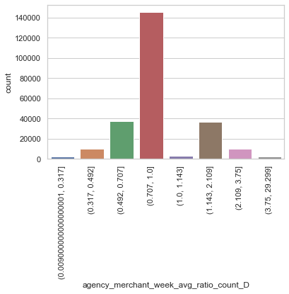

```python
# cut by percentile for plotting
var = 'agency_merchant_week_avg_ratio_count'
binned_var = var + '_D'
percentile = [0,0.01,0.05,0.2,0.5,0.8,0.95,0.99,1]
train9[binned_var] = pd.qcut( train9[var],percentile,duplicates = 'drop')
train9[['agency_merchant_week_avg_ratio_count']]

import matplotlib.pyplot as plt
plt.figure(figsize=(6,4))
g = sns.countplot(x="agency_merchant_week_avg_ratio_count_D", data=train9)
g.set_xticklabels(g.get_xticklabels(), rotation=90)
```

- From the above chart, we can see the 1% anomalies are those card holders whose ratios are greater than 3.75.
- It means these anomalies have number of transactions at least 3.75 times the average number of transactions by week.

Create features for the test set

```python
# Calculate total number of transactions group by agency, merchant category, and month

# get row counts per group
stat_by_week = test.groupby(['Agency_Name', 'Merchant_Category','Week_Number']).size()
stat_by_week = pd.DataFrame(stat_by_week)
stat_by_week.columns = ['Total_count']
stat_by_week = stat_by_week.reset_index()

# Number of card holders in each group
test["Full_Name"] = test["Cardholder_First_Initial"] + test["Cardholder_Last_Name"] # create new variable
# count number of unique names as number of card holders
number_cardholder_by_week = test.groupby(['Agency_Name', 'Merchant_Category','Week_Number'])['Full_Name'].nunique()
number_cardholder_by_week = pd.DataFrame(number_cardholder_by_week)
number_cardholder_by_week.columns = ['Number_of_cardholders']

test9 = pd.merge(stat_by_week, number_cardholder_by_week, how='left', on=['Agency_Name', 'Merchant_Category','Week_Number'])
test9['AVG_count'] = np.where(test9['Number_of_cardholders']==0,0, test9['Total_count'] / test9['Number_of_cardholders'])

c = df.groupby(['Cardholder_Last_Name','Cardholder_First_Initial','Agency_Name','Merchant_Category','Week_Number']).size()
c = pd.DataFrame(c)
c.columns = ['Number_of_transactions']
c = c.reset_index()

# add the new feature average spending to the dataset
test9 = pd.merge(c, test9, how='left', on=['Agency_Name', 'Merchant_Category','Week_Number'])

test9['agency_merchant_week_avg_ratio_count'] = np.where(test9['AVG_count']==0,0, test9['Number_of_transactions'] / test9['AVG_count'])
test9['agency_merchant_week_avg_ratio_count'].describe()
```

```
count    188464.000000
mean          1.454835
std           1.360629
min           0.029412
25%           0.941176
50%           1.000000
75%           1.555556
max          44.820513
Name: agency_merchant_week_avg_ratio_count, dtype: float64
```

### 3.10 Feature 10: The ratio to average number of transactions by day of week

Back to Table of Contents

My thought process:

- The process of creating this feature is similar to what we did in the last feature, the only difference is that we replace "week" with "dayOfweek".
- Choosing day of week to aggregate might be helpful to catch more anomalies.

```python
# Calculate total number of transactions group by agency, merchant category, and day of week

# get row counts per group
stat_by_day = train.groupby(['Agency_Name', 'Merchant_Category','Day_of_Week']).size()
stat_by_day = pd.DataFrame(stat_by_day)
stat_by_day.columns = ['Total_count']
stat_by_day = stat_by_day.reset_index()

# Number of card holders in each group
train["Full_Name"] = train["Cardholder_First_Initial"] + train["Cardholder_Last_Name"] # create new variable
# count number of unique names as number of card holders
number_cardholder_by_day = train.groupby(['Agency_Name', 'Merchant_Category','Day_of_Week'])['Full_Name'].nunique()
number_cardholder_by_day = pd.DataFrame(number_cardholder_by_day)
number_cardholder_by_day.columns = ['Number_of_cardholders']

train10 = pd.merge(stat_by_day, number_cardholder_by_day, how='left', on=['Agency_Name', 'Merchant_Category','Day_of_Week'])
train10['AVG_count'] = np.where(train10['Number_of_cardholders']==0,0, train10['Total_count'] / train10['Number_of_cardholders'])
```

```python
c = df.groupby(['Cardholder_Last_Name','Cardholder_First_Initial','Agency_Name','Merchant_Category','Day_of_Week']).size()
c = pd.DataFrame(c)
c.columns = ['Number_of_transactions']
c = c.reset_index()

# add the new feature average spending to the dataset
train10 = pd.merge(c, train10, how='left', on=['Agency_Name', 'Merchant_Category','Day_of_Week'])

train10['agency_merchant_day_avg_ratio_count'] = np.where(train10['AVG_count']==0,0, train10['Number_of_transactions'] / train10['AVG_count'])
train10['agency_merchant_day_avg_ratio_count'].describe()
```

```
count    148751.000000
mean          1.103898
std           1.292183
min           0.002985
25%           0.548035
50%           0.830189
75%           1.203320
max          53.150826
Name: agency_merchant_day_avg_ratio_count, dtype: float64
```

```
[Text(0, 0, '(0.00199, 0.154]'),
```

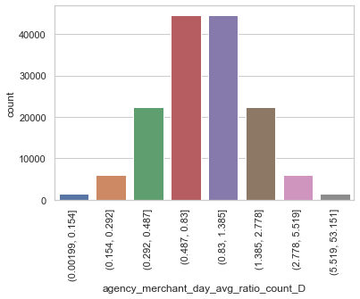

```python
# cut by percentile for plotting
var = 'agency_merchant_day_avg_ratio_count'
binned_var = var + '_D'
percentile = [0,0.01,0.05,0.2,0.5,0.8,0.95,0.99,1]
train10[binned_var] = pd.qcut( train10[var],percentile,duplicates = 'drop')
train10[['agency_merchant_day_avg_ratio_count']]

import matplotlib.pyplot as plt
plt.figure(figsize=(6,4))
g = sns.countplot(x="agency_merchant_day_avg_ratio_count_D", data=train10)
g.set_xticklabels(g.get_xticklabels(), rotation=90)
```

- From the above chart, we can see the 1% anomalies are those card holders whose ratios are greater than 5.51.
- It means these anomalies have number of transactions at least 5 times the average number of transactions by day of week.

Create features for test set

```python
stat_by_day = test.groupby(['Agency_Name', 'Merchant_Category','Day_of_Week']).size()
stat_by_day = pd.DataFrame(stat_by_day)
stat_by_day.columns = ['Total_count']
stat_by_day = stat_by_day.reset_index()

# Number of card holders in each group
test["Full_Name"] = test["Cardholder_First_Initial"] + test["Cardholder_Last_Name"] # create new variable
# count number of unique names as number of card holders
number_cardholder_by_day = test.groupby(['Agency_Name', 'Merchant_Category','Day_of_Week'])['Full_Name'].nunique()
number_cardholder_by_day = pd.DataFrame(number_cardholder_by_day)
number_cardholder_by_day.columns = ['Number_of_cardholders']

test10 = pd.merge(stat_by_day, number_cardholder_by_day, how='left', on=['Agency_Name', 'Merchant_Category','Day_of_Week'])
test10['AVG_count'] = np.where(test10['Number_of_cardholders']==0,0, test10['Total_count'] / test10['Number_of_cardholders'])

c = df.groupby(['Cardholder_Last_Name','Cardholder_First_Initial','Agency_Name','Merchant_Category','Day_of_Week']).size()
c = pd.DataFrame(c)
c.columns = ['Number_of_transactions']
c = c.reset_index()

# add the new feature average spending to the dataset
test10 = pd.merge(c, test10, how='left', on=['Agency_Name', 'Merchant_Category','Day_of_Week'])

test10['agency_merchant_day_avg_ratio_count'] = np.where(test10['AVG_count']==0,0, test10['Number_of_transactions'] / test10['AVG_count'])
test10['agency_merchant_day_avg_ratio_count'].describe()
```

```
count    132424.000000
mean          1.798251
std           2.494500
min           0.011236
25%           0.776316
50%           1.000000
75%           2.000000
max         109.516129
Name: agency_merchant_day_avg_ratio_count, dtype: float64
```

### 3.11 Feature 11: The ratio to average number of transactions during the past 30 days

Back to Table of Contents

My thought process:

- Because a fraudster want to exploit a credit card in a very short time period before the card is cancelled. If a credit card is compromised, the number of transaction of a fraudster would be extremely high compared to a normal cardholder's average number of transactions.
- Therefore, we can compare each cardholder's average number of transactions in the past 30 days to the average number of transactions over all cardholders during the past 30 days. In this way, we can identify abnormal credit card usage.
- Remember, a cardholder with high number of transactions in one day cannot be viewed as anomly, we have to compare the number to the average number of transactions at "Agency_Name" and "Merchant_category" level.

First, to get the averaged result, we need to calculate the total number of transactions for every transaction date.

```python
# Calculate the total number of transactions at agency and merchant level for every transaction date.
z = train.groupby(['Agency_Name','Merchant_Category','Transaction_Date']).size()
z = pd.DataFrame(z)
z = z.rename(columns={0: "Count"})
z = z.reset_index()
# Sort within three groups
z = z.sort_values(by = ['Agency_Name','Merchant_Category','Transaction_Date'],ascending=True).reset_index(drop=True)
```

Then, we can use rolling function and mean function to calculate the past 30 days' average number of transactions for each transaction date.

```python
z = z.set_index('Transaction_Date') # rolling function needs datetime index

# Calculate average number of transactions of past 30 days
z = z.groupby(['Agency_Name','Merchant_Category'])['Count'].rolling('30D').mean()
z = pd.DataFrame(z)
```

Now we calculate the average number of transactions of **each cardholder** in the past 30 days. The aggregation happens at cardholder's first name, last name, agency_name, merchant_category, and transaction_date level.

```python
c = train.groupby(['Cardholder_Last_Name','Cardholder_First_Initial','Agency_Name','Merchant_Category','Transaction_Date']).size()
c = pd.DataFrame(c)
c = c.rename(columns={0:'individual_count'})
c = c.reset_index()

# Sort within three groups
c = c.sort_values(by = ['Agency_Name','Merchant_Category','Transaction_Date'],ascending=True).reset_index(drop=True)
```

```python
c = c.set_index('Transaction_Date') # rolling function needs datetime index

# Calcualte average number of transactions of past 30 days
c = c.groupby(['Cardholder_Last_Name','Cardholder_First_Initial','Agency_Name','Merchant_Category'])['individual_count'].rolling('30D').mean()
c = pd.DataFrame(c)

# reset index after group by
c = c.reset_index()
```

Next, we merge two data tables by 'Agency_Name', 'Merchant_Category','Transaction_Date' level.

We compare each cardholder's average number of last 30 days' transactions to the average number of transactions at 'Agency_Name', 'Merchant_Category' level.

```python
# merge two data tables
train11 = pd.merge(c, z, how='left', on=['Agency_Name', 'Merchant_Category','Transaction_Date'])
# Feature 10: ratio to average number of transactions in the past 30 days
train11['ratio_avg_count_30days'] = np.where(train11['Count']==0,0, train11['individual_count'] / train11['Count'])
train11['ratio_avg_count_30days'].describe() # get summary statistics of ratio
```

```
count    260457.000000
mean          0.542958
std           0.373437
min           0.024390
25%           0.192926
50%           0.500000
75%           0.892857
max          12.463768
Name: ratio_avg_count_30days, dtype: float64
```

Similarly, we cut the ratio by percentile and plot it.

```
[Text(0, 0, '(0.0234, 0.0545]'),
```

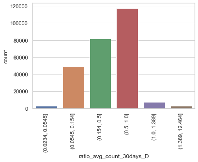

```python
# cut by percentile for plotting
var = 'ratio_avg_count_30days'
binned_var = var + '_D'
percentile = [0,0.01,0.2,0.5,0.8,0.99,1]
train11[binned_var] = pd.qcut( train11[var],percentile)
train11[['ratio_avg_count_30days']]

import matplotlib.pyplot as plt
plt.figure(figsize=(6,4))
g = sns.countplot(x="ratio_avg_count_30days_D", data=train11)
g.set_xticklabels(g.get_xticklabels(), rotation=90)
```

Thought process:

Create features for test set

```python
# Calculate the total number of transactions at agency and merchant level for every transaction date.
z = test.groupby(['Agency_Name','Merchant_Category','Transaction_Date']).size()
z = pd.DataFrame(z)
z = z.rename(columns={0: "Count"})
z = z.reset_index()
# Sort within three groups
z = z.sort_values(by = ['Agency_Name','Merchant_Category','Transaction_Date'],ascending=True).reset_index(drop=True)

z = z.set_index('Transaction_Date') # rolling function needs datetime index

# Calculate average number of transactions of past 30 days
z = z.groupby(['Agency_Name','Merchant_Category'])['Count'].rolling('30D').mean()
z = pd.DataFrame(z)

c = test.groupby(['Cardholder_Last_Name','Cardholder_First_Initial','Agency_Name','Merchant_Category','Transaction_Date']).size()
c = pd.DataFrame(c)
c = c.rename(columns={0:'individual_count'})
c = c.reset_index()

# Sort within three groups
c = c.sort_values(by = ['Agency_Name','Merchant_Category','Transaction_Date'],ascending=True).reset_index(drop=True)

c = c.set_index('Transaction_Date') # rolling function needs datetime index

# Calcualte average number of transactions of past 30 days
c = c.groupby(['Cardholder_Last_Name','Cardholder_First_Initial','Agency_Name','Merchant_Category'])['individual_count'].rolling('30D').mean()
c = pd.DataFrame(c)

# reset index after group by
c = c.reset_index()

# merge two data tables
test11 = pd.merge(c, z, how='left', on=['Agency_Name', 'Merchant_Category','Transaction_Date'])
# Feature 10: ratio to average number of transactions in the past 30 days
test11['ratio_avg_count_30days'] = np.where(test11['Count']==0,0, test11['individual_count'] / test11['Count'])
test11['ratio_avg_count_30days'].describe() # get summary statistics of ratio
```

```
count    76184.000000
mean         0.731139
std          0.292630
min          0.115789
25%          0.490196
50%          0.777778
75%          1.000000
max          5.322581
Name: ratio_avg_count_30days, dtype: float64
```

### 3.12 Feature 12: The ratio to average number of transactions during the past 60 days

Back to Table of Contents

My thought process:

- The process of creating this feature is the same as creating 10th feature. The only difference is that we replace "30days" with "60 days".
- We hope a longer time period can catch more patterns and anomalies.

```python
# Calculate the total number of transactions per day at agency and merchant level.
z = df.groupby(['Agency_Name','Merchant_Category','Transaction_Date']).size()
z = pd.DataFrame(z)
z = z.rename(columns={0: "Count"})
z = z.reset_index()
# Sort within two groups
z = z.sort_values(by = ['Agency_Name','Merchant_Category','Transaction_Date'],ascending=True).reset_index(drop=True)
```

```python
z = z.set_index('Transaction_Date') # rolling function needs datetime index

# Calculate average number of transactions of past 60 days
z = z.groupby(['Agency_Name','Merchant_Category'])['Count'].rolling('60D').mean()
z = pd.DataFrame(z)
```

Now we calculate the average number of transactions of each cardholder in the past 60 days. The aggregation happens at cardholder's first name, last name, agency_name, merchant_category, and transaction_date level.

```python
c = df.groupby(['Cardholder_Last_Name','Cardholder_First_Initial','Agency_Name','Merchant_Category','Transaction_Date']).size()
c = pd.DataFrame(c)
c = c.rename(columns={0:'individual_count'})
c = c.reset_index()

# Sort within three groups
c = c.sort_values(by = ['Agency_Name','Merchant_Category','Transaction_Date'],ascending=True).reset_index(drop=True)
```

```python
c = c.set_index('Transaction_Date') # rolling function needs datetime index

# Calcualte average number of transactions of past 60 days
c = c.groupby(['Cardholder_Last_Name','Cardholder_First_Initial','Agency_Name','Merchant_Category'])['individual_count'].rolling('60D').mean()
c = pd.DataFrame(c)

# reset index after group by
c = c.reset_index()
```

Next, we merge two data tables at 'Agency_Name', 'Merchant_Category','Transaction_Date' level.

We compare each cardholder's average number of last 60 days' transactions to the average number of transactions at 'Agency_Name', 'Merchant_Category' level.

```python
# merge two data tables
train12 = pd.merge(c, z, how='left', on=['Agency_Name', 'Merchant_Category','Transaction_Date'])
# Feature 12: ratio to average number of transactions in the past 60 days
train12['ratio_avg_count_60days'] = np.where(train12['Count']==0,0, train12['individual_count'] / train12['Count'])
train12['ratio_avg_count_60days'].describe() # get summary statistics of ratio
```

```
count    313720.000000
mean          0.516023
std           0.379942
min           0.021053
25%           0.165156
50%           0.451613
75%           0.833333
max          14.750000
Name: ratio_avg_count_60days, dtype: float64
```

```
[Text(0, 0, '(0.0201, 0.0457]'),
```

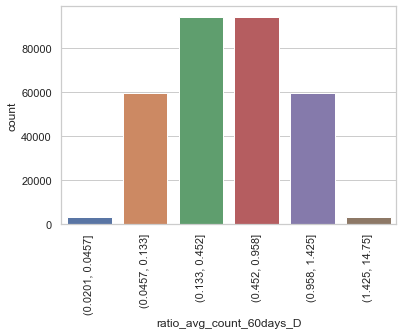

```python
# cut by percentile for plotting
var = 'ratio_avg_count_60days'
binned_var = var + '_D'
percentile = [0,0.01,0.2,0.5,0.8,0.99,1]
train12[binned_var] = pd.qcut( train12[var],percentile)
train12[['ratio_avg_count_60days']]

import matplotlib.pyplot as plt
plt.figure(figsize=(6,4))
g = sns.countplot(x="ratio_avg_count_60days_D", data=train12)
g.set_xticklabels(g.get_xticklabels(), rotation=90)
```

Thought process:

```python
train12[train12['ratio_avg_count_60days']>5].head(3)
```

|  | Cardholder_Last_Name | Cardholder_First_Initial | Agency_Name | Merchant_Category | Transaction_Date | individual_count | Count | ratio_avg_count_60days | ratio_avg_count_60days_D |
| --- | --- | --- | --- | --- | --- | --- | --- | --- | --- |
| 20134 | Baker | B | OKLAHOMA STATE UNIVERSITY | DELTA | 2013-12-30 | 21.0 | 4.000000 | 5.250000 | (1.425, 14.75] |
| 28032 | Bolser | D | DEPARTMENT OF AGRICULTURE, FOOD, ANF FOR | LODGING--HOTELS,MOTELS,AND RESORTS | 2014-05-07 | 14.0 | 2.625000 | 5.333333 | (1.425, 14.75] |
| 28097 | Bonjour | E | OKLAHOMA STATE UNIVERSITY | COMFORT HOTEL INTERNATIONAL | 2013-10-04 | 14.0 | 2.272727 | 6.160000 | (1.425, 14.75] |

Create features for test set

```python
# Calculate the total number of transactions per day at agency and merchant level.
z = test.groupby(['Agency_Name','Merchant_Category','Transaction_Date']).size()
z = pd.DataFrame(z)
z = z.rename(columns={0: "Count"})
z = z.reset_index()
# Sort within two groups
z = z.sort_values(by = ['Agency_Name','Merchant_Category','Transaction_Date'],ascending=True).reset_index(drop=True)

z = z.set_index('Transaction_Date') # rolling function needs datetime index

# Calculate average number of transactions of past 60 days
z = z.groupby(['Agency_Name','Merchant_Category'])['Count'].rolling('60D').mean()
z = pd.DataFrame(z)

c = df.groupby(['Cardholder_Last_Name','Cardholder_First_Initial','Agency_Name','Merchant_Category','Transaction_Date']).size()
c = pd.DataFrame(c)
c = c.rename(columns={0:'individual_count'})
c = c.reset_index()

# Sort within three groups
c = c.sort_values(by = ['Agency_Name','Merchant_Category','Transaction_Date'],ascending=True).reset_index(drop=True)

c = c.set_index('Transaction_Date') # rolling function needs datetime index

# Calcualte average number of transactions of past 60 days
c = c.groupby(['Cardholder_Last_Name','Cardholder_First_Initial','Agency_Name','Merchant_Category'])['individual_count'].rolling('60D').mean()
c = pd.DataFrame(c)

# reset index after group by
c = c.reset_index()

# merge two data tables
test12 = pd.merge(c, z, how='left', on=['Agency_Name', 'Merchant_Category','Transaction_Date'])
# Feature 12: ratio to average number of transactions in the past 60 days
test12['ratio_avg_count_60days'] = np.where(test12['Count']==0,0, test12['individual_count'] / test12['Count'])
test12['ratio_avg_count_60days'].describe() # get summary statistics of ratio
```

```
count    174195.000000
mean          0.802655
std           0.646109
min           0.117647
25%           0.412698
50%           0.666667
75%           1.000000
max          24.294118
Name: ratio_avg_count_60days, dtype: float64
```

### 3.13 Feature 13: The ratio to average amount at "Vendor" level

Back to Table of Contents

My thought process:

- In the last 12 features, our comparision happened at 'Agency_name' and 'Merchant_Category' level.
- What if we compare transactions at more granular level?

```python
print(df['Merchant_Category'].nunique())
print(df['Vendor'].nunique())
```

```
434
85582
```

We can see from above 'Vendor' variable has more granularity because it has more categroies than 'Merchant_Category' variable.

Next, let's create this new feature called "The ratio to average amount at Vendor level".

```python
stat_by_agency = train.groupby(['Agency_Name','Vendor'])['Amount'].mean()
stat_by_agency = pd.DataFrame(stat_by_agency)
stat_by_agency.columns = ['AVG_amount']
stat_by_agency
```

| Agency_Name | Vendor | AVG_amount |
| --- | --- | --- |
| ARDMORE HIGHER EDUCATION CENTER | CDW GOVERNMENT | 189.183333 |
|  | EMPIRE PAPER COMPANY | 443.540000 |
|  | GODADDY.COM | 18.340000 |
|  | H & S HOME CENTER | 449.000000 |
|  | HEARTLAND FOOD AND DAIRY | 145.665000 |
| ... | ... | ... |
| WORKER'S COMP. COMMISSION | STONECE.COM | 60.000000 |
| WORKERS COMPENSATION COURT | CDW GOVERNMENT | 50.000000 |
|  | DMI DELL K-12/GOVT | 91.012500 |
|  | SHI CORP | 173.666667 |
|  | SYNERGY DATACOM SUPPLY | 324.710000 |

93732 rows × 1 columns

```python
# add the new feature average spending to the dataset
train13 = pd.merge(train, stat_by_agency, how='left', on=['Agency_Name', 'Vendor'])
# Feature 13: ratio of amount spending and avergae spending by Agency_Name and vendor
train13['agency_vendor_avg_ratio_amount'] = np.where(train13['AVG_amount']==0,0, train13['Amount'] / train13['AVG_amount'])
train13['agency_vendor_avg_ratio_amount'].describe()
```

```
count    342341.000000
mean          1.000000
std           1.306839
min           0.000011
25%           0.377921
50%           0.983710
75%           1.010558
max         137.086061
Name: agency_vendor_avg_ratio_amount, dtype: float64
```

```
[Text(0, 0, '(-0.0009887000000000001, 0.0255]'),
```

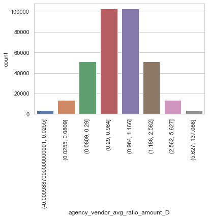

```python
# cut by percentile for plotting
var = 'agency_vendor_avg_ratio_amount'
binned_var = var + '_D'
percentile = [0,0.01,0.05,0.2,0.5,0.8,0.95,0.99,1]
train13[binned_var] = pd.qcut( train13[var],percentile)
train13[['agency_vendor_avg_ratio_amount_D']]

import matplotlib.pyplot as plt
plt.figure(figsize=(6,4))
g = sns.countplot(x="agency_vendor_avg_ratio_amount_D", data=train13)
g.set_xticklabels(g.get_xticklabels(), rotation=90)
```

- The 1% anomalies are those transactions with ratios greater than 5.6. It means these transactions have amount at least 5 times the average spending.

Create features for test set

```python
stat_by_agency = test.groupby(['Agency_Name','Vendor'])['Amount'].mean()
stat_by_agency = pd.DataFrame(stat_by_agency)
stat_by_agency.columns = ['AVG_amount']
# add the new feature average spending to the dataset
test13 = pd.merge(test, stat_by_agency, how='left', on=['Agency_Name', 'Vendor'])
# Feature 13: ratio of amount spending and avergae spending by Agency_Name and vendor
test13['agency_vendor_avg_ratio_amount'] = np.where(test13['AVG_amount']==0,0, test13['Amount'] / test13['AVG_amount'])
test13['agency_vendor_avg_ratio_amount'].describe()
```

```
count    85586.000000
mean         1.000000
std          1.150278
min          0.000025
25%          0.440029
50%          1.000000
75%          1.000000
max         68.898409
Name: agency_vendor_avg_ratio_amount, dtype: float64
```

### 3.14 Feature 14: The ratio to median amount at "Vendor" level

Back to Table of Contents

My thought process:

- The only difference is we replace 'mean' with 'median'.

```python
stat_by_agency = train.groupby(['Agency_Name','Vendor'])['Amount'].median()
stat_by_agency = pd.DataFrame(stat_by_agency)
stat_by_agency.columns = ['Median_amount']
stat_by_agency
```

| Agency_Name | Vendor | Median_amount |
| --- | --- | --- |
| ARDMORE HIGHER EDUCATION CENTER | CDW GOVERNMENT | 194.850 |
|  | EMPIRE PAPER COMPANY | 443.540 |
|  | GODADDY.COM | 18.340 |
|  | H & S HOME CENTER | 449.000 |
|  | HEARTLAND FOOD AND DAIRY | 145.665 |
| ... | ... | ... |
| WORKER'S COMP. COMMISSION | STONECE.COM | 60.000 |
| WORKERS COMPENSATION COURT | CDW GOVERNMENT | 50.000 |
|  | DMI DELL K-12/GOVT | 95.735 |
|  | SHI CORP | 217.000 |
|  | SYNERGY DATACOM SUPPLY | 324.710 |

93732 rows × 1 columns

```python
# add the new feature average spending to the dataset
train14 = pd.merge(train, stat_by_agency, how='left', on=['Agency_Name', 'Vendor'])
# Feature 14: ratio of amount spending and avergae spending by Agency_Name and merchant category
train14['agency_vendor_median_ratio_amount'] = np.where(train14['Median_amount']==0,0, train14['Amount'] / train14['Median_amount'])
train14['agency_vendor_median_ratio_amount'].describe()
```

```
count    342341.000000
mean          1.796551
std           6.387504
min           0.000013
25%           0.712980
50%           1.000000
75%           1.398015
max        1414.657692
Name: agency_vendor_median_ratio_amount, dtype: float64
```

```
[Text(0, 0, '(-0.0009875, 0.0581]'),
```

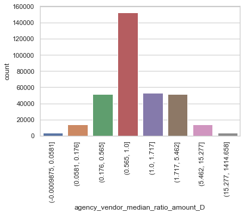

```python
# cut by percentile for plotting
var = 'agency_vendor_median_ratio_amount'
binned_var = var + '_D'
percentile = [0,0.01,0.05,0.2,0.5,0.8,0.95,0.99,1]
train14[binned_var] = pd.qcut( train14[var],percentile)
train14[['agency_vendor_median_ratio_amount_D']]

import matplotlib.pyplot as plt
plt.figure(figsize=(6,4))
g = sns.countplot(x="agency_vendor_median_ratio_amount_D", data=train14)
g.set_xticklabels(g.get_xticklabels(), rotation=90)
```

Create features for test set

```python
stat_by_agency = test.groupby(['Agency_Name','Vendor'])['Amount'].median()
stat_by_agency = pd.DataFrame(stat_by_agency)
stat_by_agency.columns = ['Median_amount']

# add the new feature average spending to the dataset
test14 = pd.merge(test, stat_by_agency, how='left', on=['Agency_Name', 'Vendor'])
# Feature 14: ratio of amount spending and avergae spending by Agency_Name and merchant category
test14['agency_vendor_median_ratio_amount'] = np.where(test14['Median_amount']==0,0, test14['Amount'] / test14['Median_amount'])
test14['agency_vendor_median_ratio_amount'].describe()
```

```
count    85586.000000
mean         1.696828
std          4.580381
min          0.000055
25%          0.808798
50%          1.000000
75%          1.237325
max        419.046512
Name: agency_vendor_median_ratio_amount, dtype: float64
```

### 3.15 Feature 15: The ratio to median amount by month at 'Vendor' level

Back to Table of Contents

My thought process:

- This feature is similar to feature 3, except we are using median and aggregation happened at 'Vendor' level.

```python
# create average spending group by agency, merchant category, and month
stat_by_month = train.groupby(['Agency_Name', 'Vendor','Month'])['Amount'].median()
stat_by_month = pd.DataFrame(stat_by_month)
stat_by_month.columns = ['AVG_amount']
stat_by_month
```

| Agency_Name | Vendor | Month | AVG_amount |
| --- | --- | --- | --- |
| ARDMORE HIGHER EDUCATION CENTER | CDW GOVERNMENT | 10 | 334.540 |
|  |  | 11 | 116.505 |
|  | EMPIRE PAPER COMPANY | 12 | 443.540 |
|  | GODADDY.COM | 10 | 18.340 |
|  | H & S HOME CENTER | 11 | 449.000 |
| ... | ... | ... | ... |
| WORKERS COMPENSATION COURT | DMI DELL K-12/GOVT | 7 | 86.290 |
|  |  | 8 | 95.735 |
|  | SHI CORP | 1 | 217.000 |
|  |  | 8 | 152.000 |
|  | SYNERGY DATACOM SUPPLY | 1 | 324.710 |

156826 rows × 1 columns

```python
# add the new feature average spending to the dataset
train15 = pd.merge(train, stat_by_month, how='left', on=['Agency_Name', 'Vendor','Month'])
# Feature 15: The ratio to Average amount spent per transaction by month
train15['agency_vendor_month_median_ratio_amount'] = np.where(train15['AVG_amount']==0,0, train15['Amount'] / train15['AVG_amount'])
train15['agency_vendor_month_median_ratio_amount'].describe()
```

```
count    342341.000000
mean          1.623780
std           5.371160
min           0.000013
25%           0.890015
50%           1.000000
75%           1.113767
max         761.787200
Name: agency_vendor_month_median_ratio_amount, dtype: float64
```

```python
# cut by percentile for plotting
var = 'agency_vendor_month_median_ratio_amount'
binned_var = var + '_D'
percentile = [0,0.01,0.05,0.2,0.5,0.8,0.95,0.99,1]
train15[binned_var] = pd.qcut( train15[var],percentile)
train15[['agency_vendor_month_median_ratio_amount_D']]
```

|  | agency_vendor_month_median_ratio_amount_D |
| --- | --- |
| 0 | (0.705, 1.0] |
| 1 | (1.372, 4.483] |
| 2 | (0.705, 1.0] |
| 3 | (0.705, 1.0] |
| 4 | (0.201, 0.705] |
| ... | ... |
| 342336 | (0.705, 1.0] |
| 342337 | (0.201, 0.705] |
| 342338 | (0.201, 0.705] |
| 342339 | (1.0, 1.372] |
| 342340 | (0.705, 1.0] |

342341 rows × 1 columns

```
[Text(0, 0, '(-0.0009875, 0.0645]'),
```

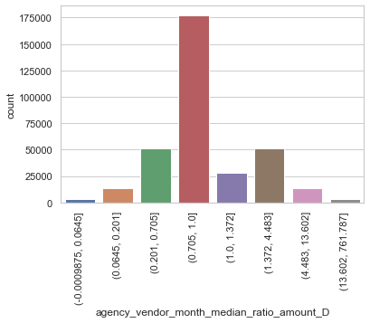

```python
import matplotlib.pyplot as plt
plt.figure(figsize=(6,4))
g = sns.countplot(x="agency_vendor_month_median_ratio_amount_D", data=train15)
g.set_xticklabels(g.get_xticklabels(), rotation=90)
```

Create features for test set

```python
stat_by_month = test.groupby(['Agency_Name', 'Vendor','Month'])['Amount'].median()
stat_by_month = pd.DataFrame(stat_by_month)
stat_by_month.columns = ['AVG_amount']

test15 = pd.merge(test, stat_by_month, how='left', on=['Agency_Name', 'Vendor','Month'])
# Feature 15: The ratio to Average amount spent per transaction by month
test15['agency_vendor_month_median_ratio_amount'] = np.where(test15['AVG_amount']==0,0, test15['Amount'] / test15['AVG_amount'])
test15['agency_vendor_month_median_ratio_amount'].describe()
```

```
count    85586.000000
mean         1.437843
std          3.646891
min          0.000063
25%          1.000000
50%          1.000000
75%          1.000000
max        511.415364
Name: agency_vendor_month_median_ratio_amount, dtype: float64
```

### Create Final Dataset

Back to Table of Contents

In the previous sections, we have aleardy created 15 features, but they are scatterd in different dataframe. Let's put them together.

```python
train['FE1_agency_merchant_avg_ratio_amount'] = train1['agency_merchant_avg_ratio_amount'].to_numpy() # copying data causes Nan value, don't know why, but 'to_numpy' solve the problem.
train['FE2_agency_merchant_median_ratio_amount'] = train2['agency_merchant_median_ratio_amount'].to_numpy()
train['FE3_agency_merchant_month_avg_ratio_amount'] = train3['agency_merchant_month_avg_ratio_amount'].to_numpy()
train['FE4_agency_merchant_week_avg_ratio_amount'] = train4['agency_merchant_week_avg_ratio_amount'].to_numpy()
train['FE5_agency_merchant_dayofweek_avg_ratio_amount'] = train5['agency_merchant_dayofweek_avg_ratio_amount'].to_numpy()
train['FE6_agency_merchant_30days_roll_ratio'] = train6['agency_merchant_30days_roll_ratio'].to_numpy()
train['FE7_agency_merchant_90days_roll_ratio'] = train7['agency_merchant_90days_roll_ratio'].to_numpy()
```

```python
train = pd.merge(train, train8[['Cardholder_Last_Name', 'Cardholder_First_Initial','Month','agency_merchant_month_avg_ratio_count','Agency_Name','Merchant_Category']],
              how='left', on=['Cardholder_Last_Name', 'Cardholder_First_Initial','Month','Agency_Name','Merchant_Category'])

train= train.rename(columns={'agency_merchant_month_avg_ratio_count': 'FE8_agency_merchant_month_avg_ratio_count'})
```

```python
train = pd.merge(train, train9[['Cardholder_Last_Name', 'Cardholder_First_Initial','Week_Number','agency_merchant_week_avg_ratio_count','Agency_Name','Merchant_Category']],
              how='left', on=['Cardholder_Last_Name', 'Cardholder_First_Initial','Week_Number','Agency_Name','Merchant_Category'])

train = train.rename(columns={'agency_merchant_week_avg_ratio_count': 'FE9_agency_merchant_week_avg_ratio_count'})
```

```python
train = pd.merge(train, train10[['Cardholder_Last_Name', 'Cardholder_First_Initial','Day_of_Week','agency_merchant_day_avg_ratio_count','Agency_Name','Merchant_Category']],
              how='left', on=['Cardholder_Last_Name', 'Cardholder_First_Initial','Day_of_Week','Agency_Name','Merchant_Category'])

train = train.rename(columns={'agency_merchant_day_avg_ratio_count': 'FE10_agency_merchant_day_avg_ratio_count'})
```

```python
train = pd.merge(train, train11[['Cardholder_Last_Name', 'Cardholder_First_Initial','Transaction_Date','ratio_avg_count_30days','Agency_Name','Merchant_Category']], how='left',
              on=['Cardholder_Last_Name', 'Cardholder_First_Initial','Transaction_Date','Agency_Name','Merchant_Category'])
train = train.rename(columns={'ratio_avg_count_30days': 'FE11_ratio_avg_count_30days'})

train = pd.merge(train, train12[['Cardholder_Last_Name', 'Cardholder_First_Initial','Transaction_Date','ratio_avg_count_60days','Agency_Name','Merchant_Category']], how='left',
              on=['Cardholder_Last_Name', 'Cardholder_First_Initial','Transaction_Date','Agency_Name','Merchant_Category'])

train = train.rename(columns={'ratio_avg_count_60days': 'FE12_ratio_avg_count_60days'})
```

```python
train['FE13_agency_vendor_avg_ratio_amount'] = train13['agency_vendor_avg_ratio_amount']
train['FE14_agency_vendor_median_ratio_amount'] = train14['agency_vendor_median_ratio_amount']
train['FE15_agency_vendor_month_median_ratio_amount'] = train15['agency_vendor_month_median_ratio_amount']
```

```python
train = train.iloc[:, 16:]
train.head(3)
```

|  | FE1_agency_merchant_avg_ratio_amount | FE2_agency_merchant_median_ratio_amount | FE3_agency_merchant_month_avg_ratio_amount | FE4_agency_merchant_week_avg_ratio_amount | FE5_agency_merchant_dayofweek_avg_ratio_amount | FE6_agency_merchant_30days_roll_ratio | FE7_agency_merchant_90days_roll_ratio | FE8_agency_merchant_month_avg_ratio_count | FE9_agency_merchant_week_avg_ratio_count | FE10_agency_merchant_day_avg_ratio_count | FE11_ratio_avg_count_30days | FE12_ratio_avg_count_60days | FE13_agency_vendor_avg_ratio_amount | FE14_agency_vendor_median_ratio_amount | FE15_agency_vendor_month_median_ratio_amount |
| --- | --- | --- | --- | --- | --- | --- | --- | --- | --- | --- | --- | --- | --- | --- | --- |
| 0 | 0.110978 | 0.250803 | 0.087180 | 0.069039 | 0.106033 | 0.129986 | 0.097383 | 1.956522 | 1.0 | 0.620000 | 0.571429 | 0.527273 | 0.043469 | 0.846333 | 0.922769 |
| 1 | 0.842579 | 1.869418 | 0.713848 | 0.726383 | 0.947053 | 0.786474 | 0.857465 | 0.492537 | 0.7 | 0.269231 | 0.293333 | 0.235602 | 0.856652 | 1.787283 | 2.081885 |
| 2 | 0.166686 | 0.278993 | 0.103960 | 1.000000 | 0.160469 | 1.000000 | 1.000000 | 1.000000 | 1.0 | 2.000000 | 1.000000 | 1.000000 | 0.457532 | 1.000000 | 1.000000 |

Next, we perform the same procedure on test set.

```python
test['FE1_agency_merchant_avg_ratio_amount'] = test1['agency_merchant_avg_ratio_amount'].to_numpy() # copying data causes Nan value, don't know why, but 'to_numpy' solve the problem.
test['FE2_agency_merchant_median_ratio_amount'] = test2['agency_merchant_median_ratio_amount'].to_numpy()
test['FE3_agency_merchant_month_avg_ratio_amount'] = test3['agency_merchant_month_avg_ratio_amount'].to_numpy()
test['FE4_agency_merchant_week_avg_ratio_amount'] = test4['agency_merchant_week_avg_ratio_amount'].to_numpy()
test['FE5_agency_merchant_dayofweek_avg_ratio_amount'] = test5['agency_merchant_dayofweek_avg_ratio_amount'].to_numpy()
test['FE6_agency_merchant_30days_roll_ratio'] = test6['agency_merchant_30days_roll_ratio'].to_numpy()
test['FE7_agency_merchant_90days_roll_ratio'] = test7['agency_merchant_90days_roll_ratio'].to_numpy()

test = pd.merge(test, test8[['Cardholder_Last_Name', 'Cardholder_First_Initial','Month','agency_merchant_month_avg_ratio_count','Agency_Name','Merchant_Category']],
              how='left', on=['Cardholder_Last_Name', 'Cardholder_First_Initial','Month','Agency_Name','Merchant_Category'])
test= test.rename(columns={'agency_merchant_month_avg_ratio_count': 'FE8_agency_merchant_month_avg_ratio_count'})

test = pd.merge(test, test9[['Cardholder_Last_Name', 'Cardholder_First_Initial','Week_Number','agency_merchant_week_avg_ratio_count','Agency_Name','Merchant_Category']],
              how='left', on=['Cardholder_Last_Name', 'Cardholder_First_Initial','Week_Number','Agency_Name','Merchant_Category'])
test = test.rename(columns={'agency_merchant_week_avg_ratio_count': 'FE9_agency_merchant_week_avg_ratio_count'})

test = pd.merge(test, test10[['Cardholder_Last_Name', 'Cardholder_First_Initial','Day_of_Week','agency_merchant_day_avg_ratio_count','Agency_Name','Merchant_Category']],
              how='left', on=['Cardholder_Last_Name', 'Cardholder_First_Initial','Day_of_Week','Agency_Name','Merchant_Category'])

test = test.rename(columns={'agency_merchant_day_avg_ratio_count': 'FE10_agency_merchant_day_avg_ratio_count'})
test = pd.merge(test, test11[['Cardholder_Last_Name', 'Cardholder_First_Initial','Transaction_Date','ratio_avg_count_30days','Agency_Name','Merchant_Category']], how='left',
              on=['Cardholder_Last_Name', 'Cardholder_First_Initial','Transaction_Date','Agency_Name','Merchant_Category'])
test = test.rename(columns={'ratio_avg_count_30days': 'FE11_ratio_avg_count_30days'})

test = pd.merge(test, test12[['Cardholder_Last_Name', 'Cardholder_First_Initial','Transaction_Date','ratio_avg_count_60days','Agency_Name','Merchant_Category']], how='left',
              on=['Cardholder_Last_Name', 'Cardholder_First_Initial','Transaction_Date','Agency_Name','Merchant_Category'])
test = test.rename(columns={'ratio_avg_count_60days': 'FE12_ratio_avg_count_60days'})

test['FE13_agency_vendor_avg_ratio_amount'] = test13['agency_vendor_avg_ratio_amount']
test['FE14_agency_vendor_median_ratio_amount'] = test14['agency_vendor_median_ratio_amount']
test['FE15_agency_vendor_month_median_ratio_amount'] = test15['agency_vendor_month_median_ratio_amount']
test = test.iloc[:, 16:]
test.head(3)
```

|  | FE1_agency_merchant_avg_ratio_amount | FE2_agency_merchant_median_ratio_amount | FE3_agency_merchant_month_avg_ratio_amount | FE4_agency_merchant_week_avg_ratio_amount | FE5_agency_merchant_dayofweek_avg_ratio_amount | FE6_agency_merchant_30days_roll_ratio | FE7_agency_merchant_90days_roll_ratio | FE8_agency_merchant_month_avg_ratio_count | FE9_agency_merchant_week_avg_ratio_count | FE10_agency_merchant_day_avg_ratio_count | FE11_ratio_avg_count_30days | FE12_ratio_avg_count_60days | FE13_agency_vendor_avg_ratio_amount | FE14_agency_vendor_median_ratio_amount | FE15_agency_vendor_month_median_ratio_amount |
| --- | --- | --- | --- | --- | --- | --- | --- | --- | --- | --- | --- | --- | --- | --- | --- |
| 0 | 0.532162 | 0.867684 | 0.345883 | 0.917059 | 0.550637 | 0.917059 | 0.917059 | 1.000000 | 1.000000 | 1.000000 | 0.500000 | 0.500000 | 0.917059 | 0.917059 | 0.917059 |
| 1 | 0.346295 | 0.837912 | 0.453956 | 0.449912 | 0.378883 | 0.427347 | 0.424909 | 0.888889 | 1.000000 | 1.565217 | 0.785714 | 1.011905 | 0.876406 | 1.392694 | 1.568123 |
| 2 | 1.195078 | 1.850000 | 1.643303 | 1.503125 | 1.467443 | 1.639682 | 1.417390 | 0.140625 | 6.230769 | 2.101266 | 0.296875 | 0.925000 | 1.000000 | 1.000000 | 1.000000 |

## Section 4 Modeling

Back to Table of Contents

Let’s use unsupervised KNN to detect outliers. The unsupervised k-NN method computes the Euclidean distance of an observation to other observations. The unsupervised KNN does not have any parameters to tune to make the performance better. It simply computes the distances to neighbors.

First, let's train our default KNN model with 'n_neighbors' =5. We don't want train the model every time we run this cell, so we write a if-else statement to save trained model as a pickle file.

### 4.1 Default KNN Model

Back to Table of Contents

```python
from pyod.models.knn import KNN
import pickle
import os.path

if os.path.exists('KNN_default_model.pkl'):
    print("Model file exists, Loading model.....")
    clf = pickle.load(open('KNN_default_model.pkl', 'rb'))
    y_train_scores = clf.decision_scores_
    print("Done, model loaded")

else:
    print("Missing model file, start training.....")
    X_train = train
    clf_name = 'KNN'
    clf = KNN()
    clf.fit(X_train)
    # save model
    pickle.dump(clf, open('KNN_default_model.pkl', 'wb'))
    # If you want to see the predictions of the training data, you can use this way:
    y_train_scores = clf.decision_scores_
```

```
Model file exists, Loading model.....
Done, model loaded
```

```python
y_train_scores
```

```
array([0.49263224, 0.45431274, 0.65421208, ..., 0.68707768, 0.71040909,
       0.68981346])
```

With our trained KNN model, we can apply it to the test data and get the predictions and anomaly scores.

How is the “anomaly score” defined? Recall the k-NN model uses the Euclidean distance to measure the distance.

Since an outlier is the point that is distant from neighboring points, the outlier score is defined as the distance to its k-th nearest neighbor.

Each point will have an outlier score. Our job is to find those points with high outlier scores.

```python
# Now we have the trained K-NN model, let's apply to the test data to get the predictions
X_test = test

y_test_pred = clf.predict(X_test) # outlier labels (0 or 1)
unique, counts = np.unique(y_test_pred, return_counts=True)
print(dict(zip(unique, counts)))
# And you can generate the anomaly score using clf.decision_function:
y_test_scores = clf.decision_function(X_test)
```

```
{0: 61283, 1: 24303}
```

From above, we can see 24303 data points are being classified as outliers.

#### Determine a reasonable boundary

A data point with a high anomaly score is abnormal. We can cut anomaly scores into percentile and use a histogram to find those points. The histogram below shows the count by the anomaly score percentile.

Most of the data points have low anomaly scores. The graph shows 95% data points have anomaly scores below 2.698.

If we choose 2.698 to be the cut point, we can suggest those >=2.698 to be outliers. Notice we use the anomaly scores of the training data to determine the boundary.

```
[Text(0, 0, '(-0.001, 0.0192]'),
```

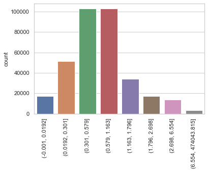

```python
percentile = [0,0.01,0.05,0.2,0.5,0.8,0.9,0.95,0.99,1]
a = pd.qcut(y_train_scores,percentile,duplicates = 'drop')

import matplotlib.pyplot as plt
plt.figure(figsize=(6,4))
g = sns.countplot(x=a)
g.set_xticklabels(g.get_xticklabels(), rotation=90)
```

```python
# Let's see how many '0's and '1's. We get 70629 '0's and 14957 '1's.
df_test = pd.DataFrame(X_test)
df_test['score'] = y_test_scores
df_test['cluster'] = np.where(df_test['score']<2.698, 0, 1) # decison boundary
print(df_test['cluster'].value_counts())
df_test.groupby('cluster').mean()
```

```
0    70629
1    14957
Name: cluster, dtype: int64
```

| cluster | FE1_agency_merchant_avg_ratio_amount | FE2_agency_merchant_median_ratio_amount | FE3_agency_merchant_month_avg_ratio_amount | FE4_agency_merchant_week_avg_ratio_amount | FE5_agency_merchant_dayofweek_avg_ratio_amount | FE6_agency_merchant_30days_roll_ratio | FE7_agency_merchant_90days_roll_ratio | FE8_agency_merchant_month_avg_ratio_count | FE9_agency_merchant_week_avg_ratio_count | FE10_agency_merchant_day_avg_ratio_count | FE11_ratio_avg_count_30days | FE12_ratio_avg_count_60days | FE13_agency_vendor_avg_ratio_amount | FE14_agency_vendor_median_ratio_amount | FE15_agency_vendor_month_median_ratio_amount | score |
| --- | --- | --- | --- | --- | --- | --- | --- | --- | --- | --- | --- | --- | --- | --- | --- | --- |
| 0 | 0.721866 | 1.517644 | 0.794647 | 0.870609 | 0.773245 | 0.803347 | 0.768495 | 1.155425 | 1.827708 | 3.78490 | 0.749365 | 0.988322 | 0.844661 | 1.185235 | 1.102462 | 0.968839 |
| 1 | 2.313387 | 7.873788 | 1.969703 | 1.611004 | 2.070767 | 1.986137 | 2.112677 | 2.566648 | 6.390983 | 18.39889 | 0.794975 | 2.139891 | 1.733533 | 4.112636 | 3.021560 | 6.796024 |

#### Interpretation & Insights

A high value in features means abnormal. The summary statistics show the average anomaly score of Cluster 1 is much higher than that of Cluster 0, indicating Cluster 1 to be the anomaly group. This is confirmed by the fact that features have lower means in Cluster 0.

All features in cluster 1 have a higher mean than that of cluster 2. For instance, the value of 'FE1_agency_merchant_avg_ratio_amount' in cluster 1 is roughly three times the value of cluster 0. This means cluster 1 has three times the average agency merchant spending compared to cluster 0.

### 4.2 Aggregating Multiple Models

Back to Table of Contents

However, many outlier detection algorithms tend to be very sensitive to outliers. In our case the unsupervised k-NN model can easily commit overfitting. We can aggregate mutiple models to produce a model with a stable outcome.

Here, we train five KNN models with different numbers of nearest neighbors.

```python
from pyod.models.combination import aom, moa, average, maximization
from pyod.utils.utility import standardizer
# Standardize data
X_train = train
X_test =  test.iloc[:,0:15]

X_train_norm, X_test_norm = standardizer(X_train, X_test)
# Test a range of k-neighbors from 10 to 200. There will be 5 k-NN models.
n_clf = 5
k_list = [10,50,100,150,200]
# Just prepare data frames so we can store the model results
train_scores = np.zeros([X_train.shape[0], n_clf])
test_scores = np.zeros([X_test.shape[0], n_clf])
train_scores.shape
# Modeling
for i in range(n_clf):
    k = k_list[i]

    if os.path.exists('KNN_model_'+str(k)+'.pkl'):
        print('KNN Model with neighbors '+ str(k)+' exists, Loading model....')
        clf = pickle.load(open('KNN_model_'+str(k)+'.pkl', 'rb'))
        print("Done, model loaded. Now, calculating anomaly scores.")
        y_train_scores = clf.decision_scores_
        test_scores[:, i] = clf.decision_function(X_test_norm)

    else:
        print("Missing model file, start training.....")
        clf = KNN(n_neighbors=k, method='largest')
        clf.fit(X_train_norm)
        # Store the results in each column:
        train_scores[:, i] = clf.decision_scores_
        test_scores[:, i] = clf.decision_function(X_test_norm)
        pickle.dump(clf, open('KNN_model_'+str(k)+'.pkl', 'wb')) # save trained models
# Decision scores have to be normalized before combination
train_scores_norm, test_scores_norm = standardizer(train_scores,test_scores)
```

```
KNN Model with neighbors 10 exists, Loading model....
Done, model loaded. Now, calculating anomaly scores.
KNN Model with neighbors 50 exists, Loading model....
Done, model loaded. Now, calculating anomaly scores.
KNN Model with neighbors 100 exists, Loading model....
Done, model loaded. Now, calculating anomaly scores.
KNN Model with neighbors 150 exists, Loading model....
Done, model loaded. Now, calculating anomaly scores.
KNN Model with neighbors 200 exists, Loading model....
Done, model loaded. Now, calculating anomaly scores.
```

#### Method 1: Average

We average the anomaly scores of five KNN model, so our model result are less prone to ourliers.

```python
y_by_average = average(test_scores_norm)
```

```
array([0.35986578, 0.41610667, 1.82804023, ..., 0.05889564, 1.34060744,
       1.32297004])
```

It is hard to visualize the anomaly scores using histogram because most values are within 0 to 1, we cut it by percentile and then plot it.

```
[Text(0, 0, '(-0.0009999999999996201, 1.53e-14]'),
```

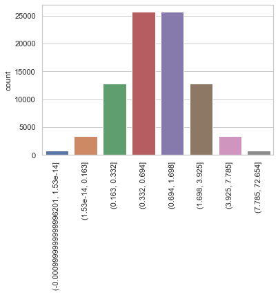

```python
percentile = [0,0.01,0.05,0.2,0.5,0.8,0.95,0.99,1]
a = pd.qcut(y_by_average,percentile)

import matplotlib.pyplot as plt
plt.figure(figsize=(6,4))
g = sns.countplot(x=a)
g.set_xticklabels(g.get_xticklabels(), rotation=90)
```

From the above graph, we can identify anoamly scores greater than 3.925 as the 5% anomalies.

We find that there are total 4279 anomalies.

```python
df_test = pd.DataFrame(X_test)
df_test['y_by_average_score'] = y_by_average
df_test['y_by_average_cluster'] = np.where(df_test['y_by_average_score']<3.925, 0, 1)
df_test['y_by_average_cluster'].value_counts()
```

```
0    81307
1     4279
Name: y_by_average_cluster, dtype: int64
```

```python
df_test.groupby('y_by_average_cluster').mean()
```

| y_by_average_cluster | FE1_agency_merchant_avg_ratio_amount | FE2_agency_merchant_median_ratio_amount | FE3_agency_merchant_month_avg_ratio_amount | FE4_agency_merchant_week_avg_ratio_amount | FE5_agency_merchant_dayofweek_avg_ratio_amount | FE6_agency_merchant_30days_roll_ratio | FE7_agency_merchant_90days_roll_ratio | FE8_agency_merchant_month_avg_ratio_count | FE9_agency_merchant_week_avg_ratio_count | FE10_agency_merchant_day_avg_ratio_count | FE11_ratio_avg_count_30days | FE12_ratio_avg_count_60days | FE13_agency_vendor_avg_ratio_amount | FE14_agency_vendor_median_ratio_amount | FE15_agency_vendor_month_median_ratio_amount | y_by_average_score | y_by_maximization_score | y_by_maximization_cluster | y_by_aom_score | y_by_aom_cluster |
| --- | --- | --- | --- | --- | --- | --- | --- | --- | --- | --- | --- | --- | --- | --- | --- | --- | --- | --- | --- | --- |
| 0 | 0.903704 | 2.202982 | 0.939422 | 0.969237 | 0.931019 | 0.948364 | 0.929360 | 1.264885 | 2.240355 | 4.979299 | 0.751310 | 1.081509 | 0.950811 | 1.491802 | 1.299071 | 0.940417 | 1.052936 | 0.057252 | 0.940417 | 0.052652 |
| 1 | 2.829753 | 10.712799 | 2.151075 | 1.584536 | 2.310727 | 2.182182 | 2.410335 | 4.008391 | 9.937507 | 32.172003 | 0.871828 | 3.242892 | 1.934659 | 5.592606 | 4.074709 | 6.386301 | 7.014564 | 1.000000 | 6.386301 | 1.000000 |

##### Interpretation & Insights

Cluster 1 is the anomaly group. We can observe it has an average score of 6.38, which is seven times the score of cluster 0. In terms of features, we can easily see a huge difference between cluster 0 and cluster 1. For example, cluster 1 has an agency merchant median ratio of 10. That is 5 times the ratio of cluster 0. This huge ratio convinces us the cluster 1 is the anomaly group.

#### Method 2: The Maximum of Maximum (MOM)

We take the maximum of the anomaly scores from five KNN model, so our model result are less prone to ourliers.

```
[Text(0, 0, '(-0.000999999999999067, 2.19e-14]'),
```

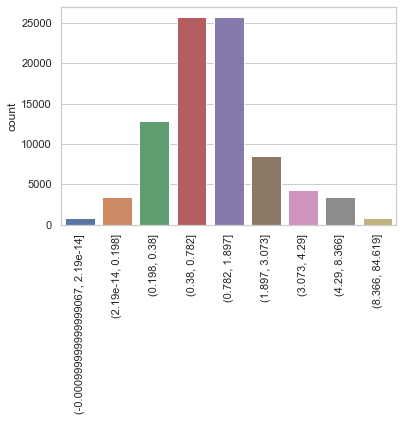

```python
y_by_maximization = maximization(test_scores_norm)
percentile = [0,0.01,0.05,0.2,0.5,0.8,0.9,0.95,0.99,1]
a = pd.qcut(y_by_maximization,percentile)
import matplotlib.pyplot as plt
plt.figure(figsize=(6,4))
g = sns.countplot(x=a)
g.set_xticklabels(g.get_xticklabels(), rotation=90)
```

From the above graph, we can identify anoamly scores greater than 3.073 as the 10% anomalies.

We find that there are total 8934 anomalies.

```python
df_test = pd.DataFrame(X_test)
df_test['y_by_maximization_score'] = y_by_maximization
df_test['y_by_maximization_cluster'] = np.where(df_test['y_by_maximization_score']<3, 0, 1)
df_test['y_by_maximization_cluster'].value_counts()
```

```
0    76652
1     8934
Name: y_by_maximization_cluster, dtype: int64
```

```python
df_test.groupby('y_by_maximization_cluster').mean()
```

| y_by_maximization_cluster | FE1_agency_merchant_avg_ratio_amount | FE2_agency_merchant_median_ratio_amount | FE3_agency_merchant_month_avg_ratio_amount | FE4_agency_merchant_week_avg_ratio_amount | FE5_agency_merchant_dayofweek_avg_ratio_amount | FE6_agency_merchant_30days_roll_ratio | FE7_agency_merchant_90days_roll_ratio | FE8_agency_merchant_month_avg_ratio_count | FE9_agency_merchant_week_avg_ratio_count | FE10_agency_merchant_day_avg_ratio_count | FE11_ratio_avg_count_30days | FE12_ratio_avg_count_60days | FE13_agency_vendor_avg_ratio_amount | FE14_agency_vendor_median_ratio_amount | FE15_agency_vendor_month_median_ratio_amount | y_by_average_score | y_by_average_cluster | y_by_maximization_score |
| --- | --- | --- | --- | --- | --- | --- | --- | --- | --- | --- | --- | --- | --- | --- | --- | --- | --- | --- |
| 0 | 0.847732 | 2.012232 | 0.895758 | 0.940398 | 0.882627 | 0.904399 | 0.879478 | 1.203857 | 1.997138 | 4.374398 | 0.746694 | 0.997931 | 0.918457 | 1.398177 | 1.234970 | 0.800087 | 0.122945 | 0.899313 |
| 1 | 2.306432 | 7.915420 | 1.894380 | 1.511373 | 2.007034 | 1.916523 | 2.066664 | 3.102513 | 8.013716 | 23.193369 | 0.848640 | 2.833801 | 1.699623 | 4.259191 | 3.178458 | 4.752769 | 1.000000 | 5.226350 |

##### Interpretation & Insights

All features in cluster 1 are larger than the features in cluster 0.  
For example, cluster 1 has an agency merchant median ratio of 7.9. That is 4 times the ratio of cluster 0. This huge ratio convinces us the cluster 1 is the anomaly group.

#### Method 3: The Average of Maximum (AOM)

We use the Average-of-Maximum method and hope our model result are less prone to ourliers.

```
[Text(0, 0, '(-0.0009999999999996201, 1.53e-14]'),
```

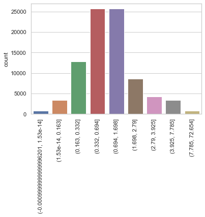

```python
y_by_aom = aom(test_scores_norm, n_buckets=5)
percentile = [0,0.01,0.05,0.2,0.5,0.8,0.9,0.95,0.99,1]
a = pd.qcut(y_by_aom,percentile)
import matplotlib.pyplot as plt
plt.figure(figsize=(6,4))
g = sns.countplot(x=a)
g.set_xticklabels(g.get_xticklabels(), rotation=90)
```

From the above graph, we can identify anoamly scores greater than 2.79 as the 10% anomalies.

We find that there are total 8560 anomalies.

```python
df_test = pd.DataFrame(X_test)
df_test['y_by_aom_score'] = y_by_aom
df_test['y_by_aom_cluster'] = np.where(df_test['y_by_aom_score']<2.79, 0, 1)
df_test['y_by_aom_cluster'].value_counts()
```

```
0    77026
1     8560
Name: y_by_aom_cluster, dtype: int64
```

```python
df_test.groupby('y_by_aom_cluster').mean()
```

| y_by_aom_cluster | FE1_agency_merchant_avg_ratio_amount | FE2_agency_merchant_median_ratio_amount | FE3_agency_merchant_month_avg_ratio_amount | FE4_agency_merchant_week_avg_ratio_amount | FE5_agency_merchant_dayofweek_avg_ratio_amount | FE6_agency_merchant_30days_roll_ratio | FE7_agency_merchant_90days_roll_ratio | FE8_agency_merchant_month_avg_ratio_count | FE9_agency_merchant_week_avg_ratio_count | FE10_agency_merchant_day_avg_ratio_count | FE11_ratio_avg_count_30days | FE12_ratio_avg_count_60days | FE13_agency_vendor_avg_ratio_amount | FE14_agency_vendor_median_ratio_amount | FE15_agency_vendor_month_median_ratio_amount | y_by_average_score | y_by_average_cluster | y_by_maximization_score | y_by_maximization_cluster | y_by_aom_score |
| --- | --- | --- | --- | --- | --- | --- | --- | --- | --- | --- | --- | --- | --- | --- | --- | --- | --- | --- | --- | --- |
| 0 | 0.857276 | 2.045698 | 0.902299 | 0.94443 | 0.89010 | 0.911015 | 0.887576 | 1.206943 | 2.011341 | 4.405595 | 0.746870 | 1.003301 | 0.922549 | 1.410437 | 1.242045 | 0.809306 | 0.127204 | 0.909941 | 0.005180 | 0.809306 |
| 1 | 2.284278 | 7.872195 | 1.879148 | 1.50004 | 1.98892 | 1.901211 | 2.045663 | 3.157702 | 8.148781 | 23.734870 | 0.851516 | 2.865693 | 1.696931 | 4.273876 | 3.199703 | 4.842508 | 1.000000 | 5.319778 | 0.997079 | 4.842508 |

##### Interpretation & Insights

All features in cluster 1 are larger than the features in cluster 0.  
For example, cluster 1 has an agency merchant median ratio of 7.87. That is approximately 4 times the ratio of cluster 0.

We have strong confidence in believing that cluster 1 is the anomaly group.

#### Method 4: The maximum of average (MOA)

We use the Maximum-of-Average method and hope our model result are less prone to ourliers.

```
[Text(0, 0, '(-0.000999999999999067, 2.19e-14]'),
```

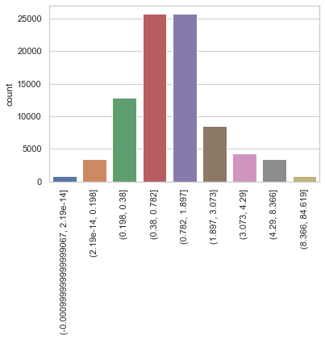

```python
y_by_moa = moa(test_scores_norm, n_buckets=5)
percentile = [0,0.01,0.05,0.2,0.5,0.8,0.9,0.95,0.99,1]
a = pd.qcut(y_by_moa,percentile)
import matplotlib.pyplot as plt
plt.figure(figsize=(6,4))
g = sns.countplot(x=a)
g.set_xticklabels(g.get_xticklabels(), rotation=90)
```

From the above graph, we can identify anoamly scores greater than 3.073 as the 10% anomalies.

We find that there are total 7212 anomalies.

```python
df_test = pd.DataFrame(X_test)
df_test['y_by_moa_score'] = y_by_aom
df_test['y_by_moa_cluster'] = np.where(df_test['y_by_moa_score']<3.079, 0, 1)
df_test['y_by_moa_cluster'].value_counts()
```

```
0    78374
1     7212
Name: y_by_moa_cluster, dtype: int64
```

```python
df_test.groupby('y_by_moa_cluster').mean()
```

| y_by_moa_cluster | FE1_agency_merchant_avg_ratio_amount | FE2_agency_merchant_median_ratio_amount | FE3_agency_merchant_month_avg_ratio_amount | FE4_agency_merchant_week_avg_ratio_amount | FE5_agency_merchant_dayofweek_avg_ratio_amount | FE6_agency_merchant_30days_roll_ratio | FE7_agency_merchant_90days_roll_ratio | FE8_agency_merchant_month_avg_ratio_count | FE9_agency_merchant_week_avg_ratio_count | FE10_agency_merchant_day_avg_ratio_count | ... | FE13_agency_vendor_avg_ratio_amount | FE14_agency_vendor_median_ratio_amount | FE15_agency_vendor_month_median_ratio_amount | y_by_average_score | y_by_average_cluster | y_by_maximization_score | y_by_maximization_cluster | y_by_aom_score | y_by_aom_cluster | y_by_moa_score |
| --- | --- | --- | --- | --- | --- | --- | --- | --- | --- | --- | --- | --- | --- | --- | --- | --- | --- | --- | --- | --- | --- |
| 0 | 0.874037 | 2.098833 | 0.915924 | 0.953077 | 0.904433 | 0.924404 | 0.902970 | 1.224148 | 2.076351 | 4.581647 | ... | 0.932658 | 1.440776 | 1.259772 | 0.845757 | 0.000000 | 0.949842 | 0.021972 | 0.845757 | 0.0172 | 0.845757 |
| 1 | 2.368859 | 8.383803 | 1.913673 | 1.509923 | 2.038540 | 1.940790 | 2.094839 | 3.335345 | 8.589466 | 25.434534 | ... | 1.731814 | 4.479380 | 3.372968 | 5.200245 | 0.593317 | 5.710409 | 1.000000 | 5.200245 | 1.0000 | 5.200245 |

2 rows × 22 columns

##### Interpretation & Insights

All features in cluster 1 are larger than the features in cluster 0.  
For example, cluster 1 has an agency merchant median ratio of 8.38. That is more than 4 times the ratio of cluster 0.

We have strong confidence in believing that cluster 1 is the anomaly group.

## Section 5 Conclusion

Back to Table of Contents

In this fraud detection project, we created 15 features from the raw transaction dataset. Then we used unsupervised learning to detect anomalies based on the prediction scores.

We trained a total of five models and used model combination techniques including average method, MOM, AOM, and MOA to prevent overfitting.

Our models can detect top percentile anomalies. These anomalies are validated by the difference between the normal and anomaly clusters.

## Section 6 Reference

Dr.Chris Kuo . “Anomaly Detection with PyOD!” https://medium.com/dataman-in-ai/anomaly-detection-with-pyod-b523fc47db9